# Campaign Contributions and Bureaucratic Oversight

A Case Study of the Federal Energy Regulatory Commission"

Eleanor Neff Powell, Devin Judge-Lord, Justin Grimmer

# Data

```r
load(here("data/all_contacts.RData"))
# one obs per member per letter for all agencies
d <- all_contacts %>%
  ungroup() %>%
  # define d as just FERC
  filter(agency=="DOE_FERC") %>%
  select(-SUBJECT) %>%
  mutate(majority = ifelse(majority == 1, "Majority", "Minority")) %>%
  # FIXME
  # GOODE needs to be fixed in party switchers portion of merge.R
  filter(!(last_name == "GOODE"&party == "(I)"))


# one obs per member per letter per committee for all agencies
load(here("data/all_contacts_committees.RData"))
# define dcommittees as just FERC
dcommittees <- all_contacts_committees %<>% filter(agency == "DOE_FERC")

# Coded letters, one obs per member per letter
load(here("data/DOE_FERC-letters-coded.RData"))
# TO DO: replace with DOE_FERC-letters-corps.Rdata when corps added
FERC_letters %<>%
  select(ID, SUBJECT,
         Freelancer, Cosigned_House, Cosigned_Senate,
         text_clean, Constituent, year,
         Place_State, Place_District, Place_District,
         ProBusiness, AntiBusiness, ProProject, AntiProject) %>%
  distinct()

# merge in coded letters
d %<>% left_join(FERC_letters) %>% filter(year <2019)

# Add hand-coding to auto-coding of letter type
d %<>%
  mutate(Type = as.character(Type)) %>%
  mutate(Type = ifelse(tolower(Constituent) == "yes", "Indiv. Constituent", Type)) %>%
  mutate(Type = ifelse(!is.na(ProBusiness)|!is.na(ProProject), "Corp. Constituent", Type))%>%
  # define Constituent as "Indiv. Constituent"
  mutate(Constituent = ifelse(Type == "Indiv. Constituent", "Indiv. Constituent", "Non_constituent"),
         Constituent = replace_na(Constituent, "Not coded") )


# For this analysis, treat corp policy letters as Policy
all_contacts$Type %<>% fct_recode(Policy = "Corp. Policy")
d$Type %<>% fct_recode(Policy = "Corp. Policy")

# make a variable for the pro or anti business position of each letter
d %<>%
  mutate(letter_position = ifelse(!is.na(ProBusiness)|!is.na(ProProject), "ProBusiness", "Other"),
         letter_position = ifelse(!is.na(AntiBusiness)|!is.na(AntiProject), "AntiBusiness", letter_position),
         letter_position = ifelse(!is.na(AntiBusiness)&!is.na(ProBusiness), "Both", letter_position))

d %<>%
  # FIXME
  # rounding years up is approximate, rewrite to go Nov-Nov?
  mutate(cycle = congress*2+1786 ) %>%
  mutate(icpsryear = str_c(icpsr, cycle))
```

In all, we have 7600 letters received by FERC and marked “congressional” since 1990. Most, but not all of these are from Members of the U.S. Congress. For this paper, we focus on 4308 letters from 2000-2018.

Of the 4308 letters from 2000-2018, we identified Members of Congress in 3863. Because many are cosigned, this yeild 6058 instances of a member writing to FERC.

## By party

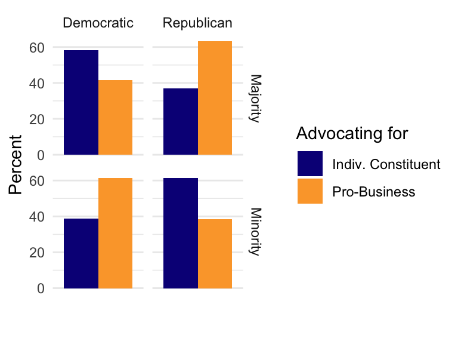

```r
d %>%
  mutate(For = Constituent,
         For = ifelse(letter_position == "ProBusiness", "Pro-Business", For),
         For = ifelse(For == "Non_constituent", "Other", For)) %>%
  count(party_name, For, majority) %>%
  filter(party_name != "Independent",
         !is.na(For),
         For != "Not coded",
         For != "Other",
         !is.na(majority)) %>%
  group_by(party_name, majority) %>%
  mutate(percent = n / sum(n) * 100 ) %>%
  ggplot() +
  aes(y = percent, x = "", fill = For) +
  geom_col(position = "dodge") +
  #geom_text(aes(label = n)) +
  facet_grid(majority ~ party_name) +
  scale_fill_viridis_d(option = "C", end = .8) +
    labs(x = "",
       fill = "Advocating for",
       y = "Percent") +
  theme_minimal() +
  theme(panel.grid.major.x  = element_blank())
```

Looking at letters that are explicitly pro- or anti- business, Democrats write more Anti-business letters, whereas, for Republicans, it depends on chamber control. Whe in the majority, Republicans write more pro-business letters.

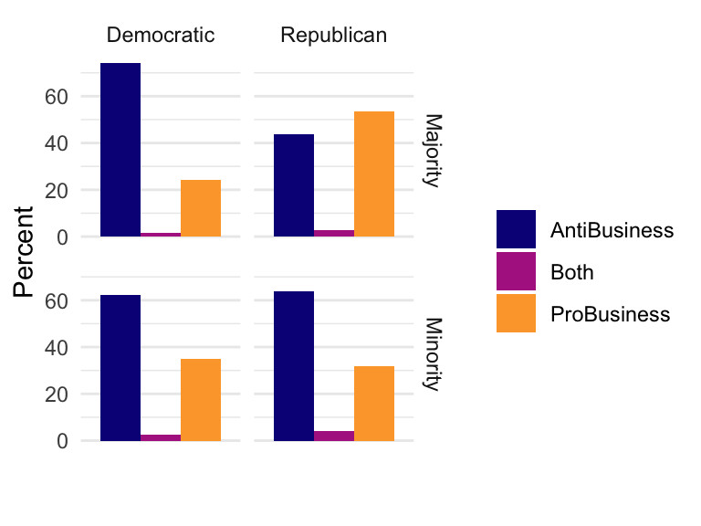

```r
d %>%
  count(party_name, letter_position, majority) %>%
    filter(party_name != "Independent",
           letter_position != "Other",
         !is.na(letter_position),
         !is.na(majority)) %>%
  group_by(party_name, majority) %>%
  mutate(percent = n / sum(n) * 100 ) %>%
  ggplot() +
  aes(y = percent, x = "", fill = letter_position) +
  geom_col(position = "dodge") +
  facet_grid(majority ~ party_name)+
  scale_fill_viridis_d(option = "C", end = .8) +
  labs(x = "",
       fill = "",
       y = "Percent") +
  theme_minimal() +
  theme(panel.grid.major.x  = element_blank())
```

## Coding of constituent type

Our coding of letter type is a mix of hand coding “Pro-business” and “Constituent” letters, as well as some coding rules applied to letters that were not put in either group by human coders using [inductively-developed coding rules](https://github.com/judgelord/correspondence/blob/master/agencies/DOE_FERC.R).

FERC has an especially high ratio of letters written on behalf of businesses compared other agencies that mostly recieve letters from legislators on behalf of their constituents.

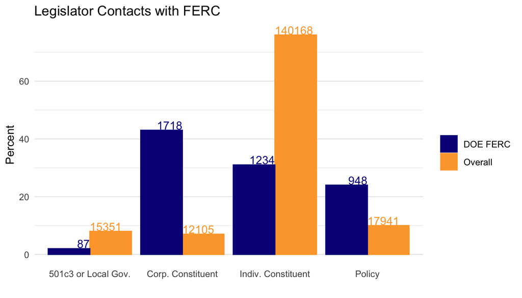

```r
all_percent <- all_contacts %>%
  filter(Type != "To be coded") %>%
  mutate(total = n()) %>%
  group_by(Type, total) %>% summarise(nT = n()) %>%
  mutate(percent = 100*round(nT/total, 2) ) %>%
  mutate(agency = "Overall") %>%
  ungroup()


d_percent <- d%>%
  filter(Type != "To be coded") %>%
  mutate(total = n()) %>%
  group_by(Type, total) %>% summarise(nT = n()) %>%
  mutate(percent = 100*round(nT/total, 2) ) %>%
  mutate(agency = "DOE FERC") %>%
  ungroup()

full_join( all_percent, d_percent)%>%
  ggplot() +
  aes(x = Type, y = percent, fill = agency, color = agency, label = nT) +
  geom_col(position = "dodge") +
  geom_text(vjust = -.1,
            aes(hjust = ifelse(agency == "Overall", 0,1))) +
  labs(x = "",
       fill = "",
       color = "",
       y = "Percent", #paste("Number of Contacts, N =", sum(nrow(all_contacts))),
       title = "Legislator Contacts with FERC") +
  theme(panel.background = element_blank(),
        axis.ticks = element_blank(),
        axis.text.x.top = element_text()) +
  scale_color_viridis_d(option = "C", end = .8) +
  scale_fill_viridis_d(option = "C", end = .8) +
    theme_minimal() +
  theme(panel.grid.major.x  = element_blank())
```

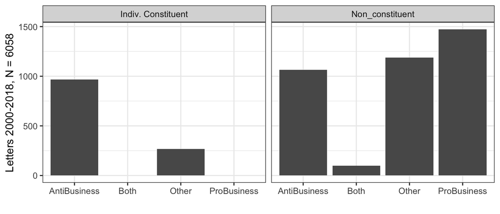

```r
d  %>%
  filter(Constituent != "Not coded") %>%
  ggplot() +
  aes(x = letter_position) +
  geom_bar() +
  facet_wrap("Constituent") +
  labs(x = "",
       y = paste("Letters 2000-2018, N =", as.character(d%>%drop_na(letter_position, Constituent) %>% nrow() %>% as.character() )))
```

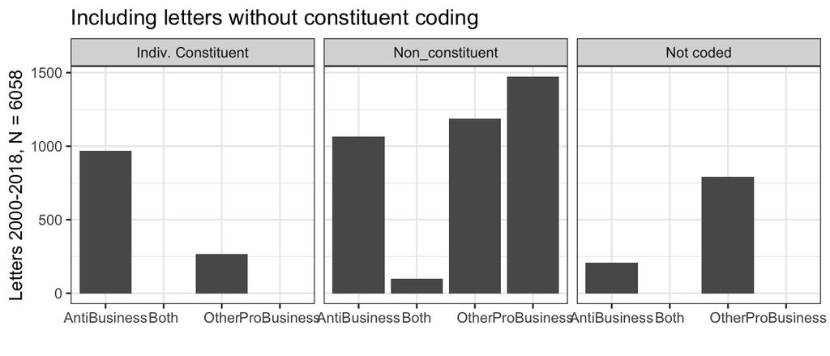

```r
d  %>%
  ggplot() +
  aes(x = letter_position) +
  geom_bar() +
  facet_wrap("Constituent") +
  labs(title = "Including letters without constituent coding",
       x = "",
       y = paste("Letters 2000-2018, N =", as.character(d %>% nrow() %>% as.character() )))
```

# Members

Of the 4308 letters from 2000-2018, we identified Members of Congress in 3863. Because many are cosigned, this yeild 6058 instances of a member writing to FERC.

### Senators vs. state population

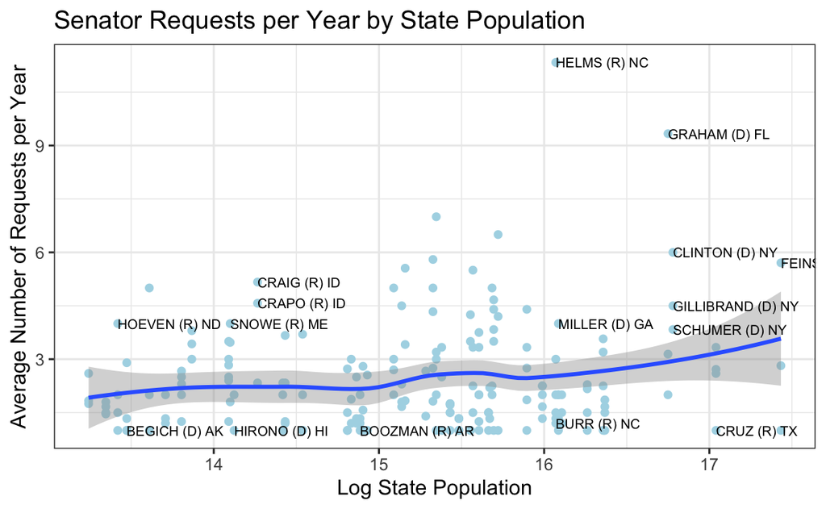

```r
d %>%
  filter(chamber == "Senate") %>%
    group_by(member_state, year, pop2010) %>% summarise(n = n()) %>%
    group_by(member_state, pop2010) %>% summarise(mean = mean(n)) %>% ungroup() %>%
    ggplot() +
    geom_point(aes(x = log(pop2010), y = mean), color = "light blue") +
  geom_smooth(aes(x = log(pop2010), y = mean)) +
  geom_text(aes(x = log(pop2010),
                y = mean,
                label = ifelse(mean > mean(mean)*1.5 | mean < mean(mean)*0.5,
                               member_state, "")),
            check_overlap = TRUE,
            size = 2.5,
            hjust = 0) +
  theme_bw() +
  labs(title = "Senator Requests per Year by State Population",
       x = "Log State Population",
       y = "Average Number of Requests per Year")
```

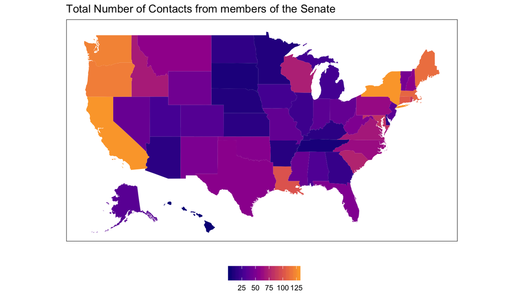

```r
Chamber = "Senate"

d %>%
  ungroup() %>%
  filter(chamber == Chamber) %>%
  group_by(state) %>% summarise(n = n()) %>%
# map_id creates the aesthetic mapping to the state name column
ggplot() +
  # map points to the fifty_states shape data
  geom_map(aes(map_id = state, fill = n), map = fifty_states) +
  expand_limits(x = fifty_states$long, y = fifty_states$lat) +
  coord_map() +
  scale_x_continuous(breaks = NULL) +
  scale_y_continuous(breaks = NULL) +
  labs(x = "", y = "", title = paste("Total Number of Contacts from members of the", Chamber)) +
  scale_fill_viridis_c(option = "C", end = .8) +
  theme(legend.position = "bottom", legend.title = element_blank(),
        panel.background = element_blank()) # + facet_grid(. ~ Constituent)
```

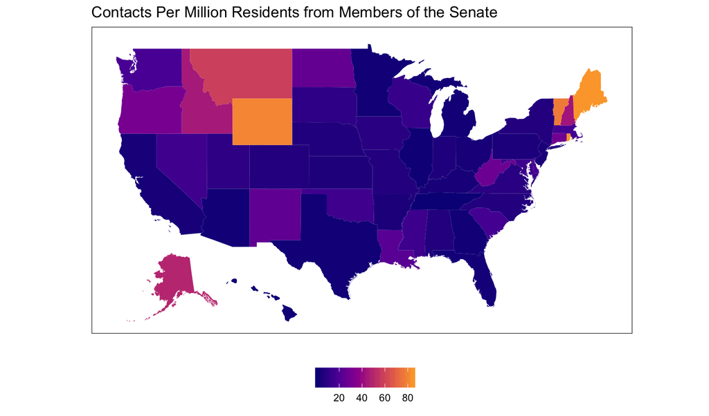

```r
d %>%
  ungroup() %>%
  filter(chamber == Chamber) %>%
  group_by(state, pop2010) %>% summarise(n = n()) %>% ungroup() %>%
  mutate(Per_Capita = n/pop2010*1000000) %>%
  # map_id creates the aesthetic mapping to the state name column in your data
  ggplot() +
  # map points to the fifty_states shape data
  geom_map(aes(map_id = state, fill = Per_Capita), map = fifty_states) +
  expand_limits(x = fifty_states$long, y = fifty_states$lat) +
  coord_map() +
  scale_x_continuous(breaks = NULL) +
  scale_y_continuous(breaks = NULL) +
  labs(x = "", y = "", title = paste("Contacts Per Million Residents from Members of the", Chamber)) +
  scale_fill_viridis_c(option = "C", end = .8) +
  theme(legend.position = "bottom",
        legend.title = element_blank() )#+facet_grid(. ~ Constituent)
```

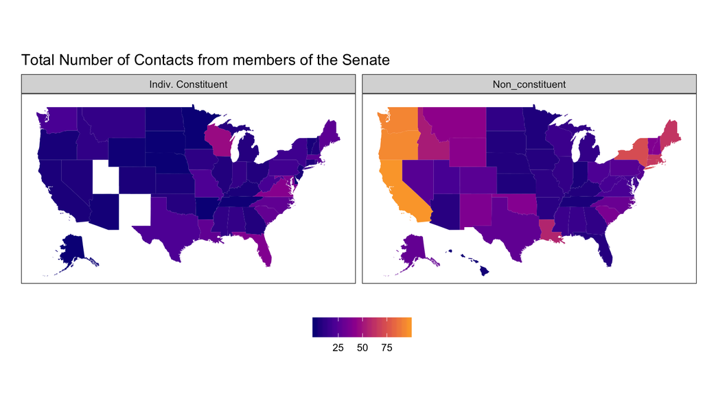

```r
# By type2
d %>%
  filter(chamber == Chamber) %>%
  filter(Constituent != "Not coded") %>%
  group_by(state, Constituent) %>% summarise(n = n()) %>%
# map_id creates the aesthetic mapping to the state name column
ggplot() +
  # map points to the fifty_states shape data
  geom_map(aes(map_id = state, fill = n), map = fifty_states) +
  expand_limits(x = fifty_states$long, y = fifty_states$lat) +
  coord_map() +
  scale_x_continuous(breaks = NULL) +
  scale_y_continuous(breaks = NULL) +
  labs(x = "", y = "", title = paste("Total Number of Contacts from members of the", Chamber)) +
  scale_fill_viridis_c(option = "C", end = .8) +
  theme(legend.position = "bottom", legend.title = element_blank(),
        panel.background = element_blank()) + facet_grid(. ~ Constituent)
```

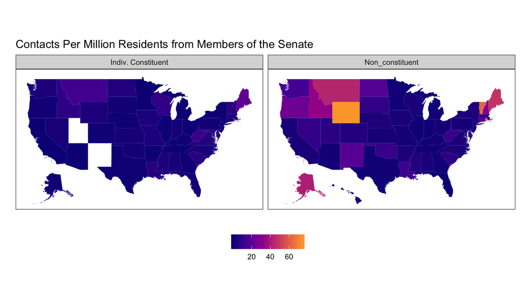

```r
d %>%
  filter(chamber == Chamber) %>%
  filter(Constituent != "Not coded") %>%
  group_by(state, pop2010, Constituent) %>% summarise(n = n()) %>% ungroup() %>%
  mutate(Per_Capita = n/pop2010*1000000) %>%
  # map_id creates the aesthetic mapping to the state name column in your data
  ggplot() +
  # map points to the fifty_states shape data
  geom_map(aes(map_id = state, fill = Per_Capita), map = fifty_states) +
  expand_limits(x = fifty_states$long, y = fifty_states$lat) +
  coord_map() +
  scale_x_continuous(breaks = NULL) +
  scale_y_continuous(breaks = NULL) +
  labs(x = "", y = "", title = paste("Contacts Per Million Residents from Members of the", Chamber)) +
  scale_fill_viridis_c(option = "C", end = .8) +
  theme(legend.position = "bottom",
        legend.title = element_blank() )+
  facet_grid(. ~ Constituent)
```

### Members who contact FERC more than average:

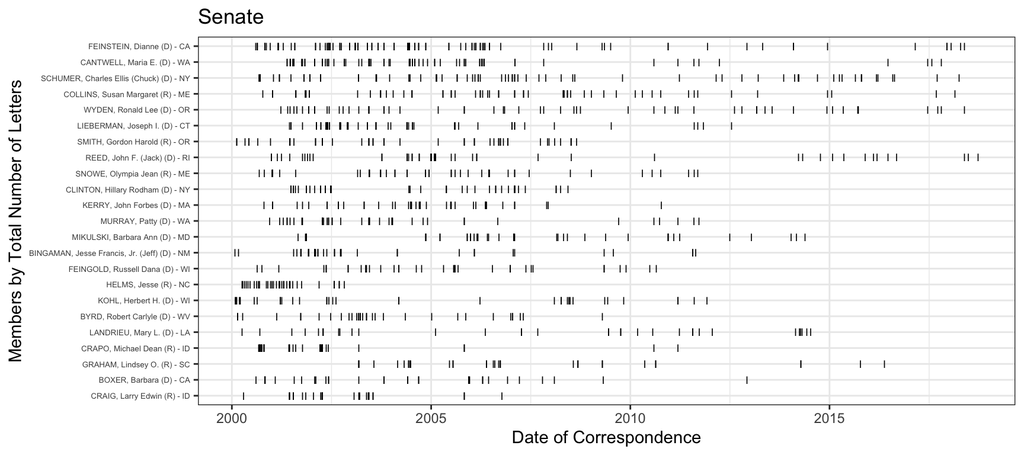

```r
# barcode plot of committee members

# member by year by agency
d %>%
  filter(chamber == Chamber) %>%
  group_by(name_state) %>% mutate(n = n()) %>% ungroup() %>%
  filter(n > mean(n)) %>%
  ggplot() +
  geom_point(
    aes(x = DATE,
        y = reorder(name_state, n) ),
    # alpha = .6,
    shape = 73,
    size=2
  ) +
  labs(title = paste(Chamber),
       y = paste("Members by", "Total Number of Letters"),
       x = "Date of Correspondence" ) +
  theme(
    legend.title = element_blank(),
    axis.text.y = element_text(size=5)
  ) +
    guides(fill=guide_legend(ncol=1))
```

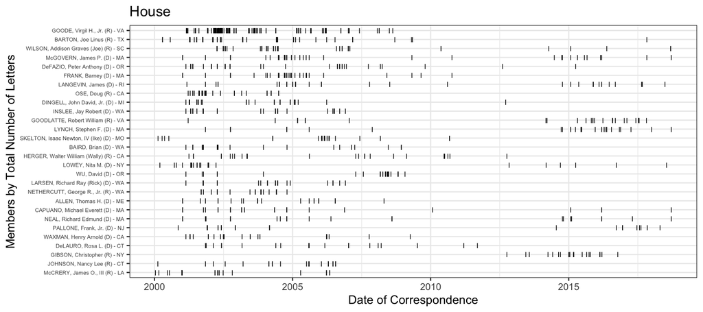

```r
Chamber <- "House" # "House" #

# member by year by agency
d %>%
  filter(chamber == Chamber) %>%
  group_by(name_state) %>% mutate(n = n()) %>% ungroup() %>%
  filter(n > mean(n)) %>%
  ggplot() +
  geom_point(
    aes(x = DATE,
        y = reorder(name_state, n) ),
    # alpha = .6,
    shape = 73,
    size=2
  ) +
  labs(title = paste(Chamber),
       y = paste("Members by", "Total Number of Letters"),
       x = "Date of Correspondence" ) +
  theme(
    legend.title = element_blank(),
    axis.text.y = element_text(size=5)
  ) +
    guides(fill=guide_legend(ncol=1))
```

### Members who contact FERC more, relative to other agencies:

```r
all_contacts %>%
  mutate(FERC = agency == "DOE_FERC") %>%
  group_by(chamber, FERC, name_state, state) %>%
  summarise(n = n() ) %>%
  ungroup() %>%
  spread(key = "FERC", value = "n") %>%
  mutate(ShareToFERC = round(`TRUE`/(`TRUE`+`FALSE`),2) ) %>%
  arrange(-ShareToFERC) %>%
  mutate(total = `TRUE` + `FALSE`) %>%
  select(name_state, chamber, total, ShareToFERC) %>%
  filter(ShareToFERC>.3) %>%
  knitr::kable()
```

| name_state | chamber | total | ShareToFERC |
| --- | --- | --- | --- |
| OSE, Doug (R) - CA | House | 31 | 0.97 |
| SARBANES, Paul Spyros (D) - MD | Senate | 23 | 0.96 |
| NETHERCUTT, George R., Jr. (R) - WA | House | 24 | 0.92 |
| TALENT, James Matthes (R) - MO | Senate | 11 | 0.91 |
| NICKLES, Donald Lee (R) - OK | Senate | 20 | 0.90 |
| DUNN, Jennifer Blackburn (R) - WA | House | 16 | 0.81 |
| OTTER, C. L. (Butch) (R) - ID | House | 5 | 0.80 |
| GREENWOOD, James Charles (R) - PA | House | 9 | 0.78 |
| CARDIN, Benjamin Louis (D) - MD | House | 4 | 0.75 |
| BILIRAKIS, Michael (R) - FL | House | 16 | 0.75 |
| ALLEN, George (R) - VA | Senate | 28 | 0.71 |
| JEFFORDS, James Merrill (I) - VT | Senate | 13 | 0.69 |
| TOOMEY, Patrick Joseph (R) - PA | House | 3 | 0.67 |
| NORTHUP, Anne Meagher (R) - KY | House | 3 | 0.67 |
| LESKO, Debbie (R) - AZ | House | 3 | 0.67 |
| JOHNSON, Nancy Lee (R) - CT | House | 30 | 0.67 |
| DASCHLE, Thomas Andrew (D) - SD | Senate | 3 | 0.67 |
| CHAFEE, Lincoln Davenport (R) - RI | Senate | 29 | 0.66 |
| BREAUX, John Berlinger (D) - LA | Senate | 45 | 0.64 |
| MILLENDER-McDONALD, Juanita (D) - CA | House | 8 | 0.62 |
| BROWN, Sherrod (D) - OH | House | 13 | 0.62 |
| HOLLINGS, Ernest Frederick (D) - SC | Senate | 20 | 0.60 |
| THOMAS, Craig Lyle (R) - WY | Senate | 22 | 0.59 |
| BURNS, Conrad (R) - MT | Senate | 27 | 0.59 |
| NUSSLE, James Allen (R) - IA | House | 9 | 0.56 |
| HOUGHTON, Amory, Jr. (R) - NY | House | 2 | 0.50 |
| GIBBONS, James A. (R) - NV | House | 14 | 0.50 |
| CRANE, Philip Miller (R) - IL | House | 2 | 0.50 |
| CARSON, Brad (D) - OK | House | 2 | 0.50 |
| TAYLOR, Charles Hart (R) - NC | House | 17 | 0.47 |
| MATSUI, Robert T. (D) - CA | House | 9 | 0.44 |
| OSBORNE, Thomas (R) - NE | House | 14 | 0.43 |
| MEEHAN, Martin Thomas (D) - MA | House | 24 | 0.42 |
| GOODE, Virgil H., Jr. (R) - VA | House | 399 | 0.41 |
| BOEHLERT, Sherwood Louis (R) - NY | House | 27 | 0.41 |
| CORZINE, Jon Stevens (D) - NJ | Senate | 22 | 0.41 |
| LAMB, Conor (D) - PA | House | 5 | 0.40 |
| PORTER, Jon C. (R) - NV | House | 23 | 0.39 |
| KELLY, Sue W. (R) - NY | House | 45 | 0.36 |
| MOONEY, Alex X. (R) - WV | House | 51 | 0.35 |
| STRICKLAND, Ted (D) - OH | House | 15 | 0.33 |
| CARSON, Julia May (D) - IN | House | 3 | 0.33 |
| DeLAY, Thomas Dale (R) - TX | House | 22 | 0.32 |
| SWEENEY, John E. (R) - NY | House | 26 | 0.31 |

### Members who contact FERC more in a Congress, relative to other agencies:

```r
all_contacts %>%
  mutate(FERC = agency == "DOE_FERC") %>%
  group_by(congress, chamber, committees, FERC, name_state, state) %>%
  summarise(n = n() ) %>%
  ungroup() %>%
  spread(key = "FERC", value = "n") %>%
  mutate(ShareToFERC = round(`TRUE`/(`TRUE`+`FALSE`),2) )%>%
  arrange(-ShareToFERC) %>%
  mutate(total = `TRUE` + `FALSE`) %>%
  select(name_state, congress, chamber, committees, total, ShareToFERC) %>%
  filter(ShareToFERC>.5, total>5) %>%
  knitr::kable()
```

| name_state | congress | chamber | committees | total | ShareToFERC |
| --- | --- | --- | --- | --- | --- |
| FRANK, Barney (D) - MA | 108 | House | FINANCIAL SERVICES\|SELECT COMMITTEE ON HOMELAND SECURITY | 20 | 0.95 |
| FEINSTEIN, Dianne (D) - CA | 107 | Senate | APPROPRIATIONS\|ENERGY\|JUDICIARY\|RULES\|INTELLIGENCE\|PRINTING | 25 | 0.92 |
| GRASSLEY, Charles Ernest (R) - IA | 107 | Senate | BUDGET\|FINANCE\|JUDICIARY | 10 | 0.90 |
| BARTON, Joe Linus (R) - TX | 108 | House | ENERGY\|SCIENCE | 10 | 0.90 |
| TALENT, James Matthes (R) - MO | 109 | Senate | AGRICULTURE\|ARMED SERVICES\|ENERGY\|AGING | 10 | 0.90 |
| SARBANES, Paul Spyros (D) - MD | 109 | Senate | BANKING\|BUDGET\|FOREIGN RELATIONS\|ECONOMIC | 10 | 0.90 |
| OSE, Doug (R) - CA | 108 | House | AGRICULTURE\|FINANCIAL SERVICES\|GOVERNMENT REFORM | 9 | 0.89 |
| CAPUANO, Michael Everett (D) - MA | 108 | House | FINANCIAL SERVICES\|TRANSPORTATION | 8 | 0.88 |
| McGOVERN, James P. (D) - MA | 108 | House | RULES | 17 | 0.88 |
| SMITH, Gordon Harold (R) - OR | 109 | Senate | COMMERCE\|ENERGY\|FINANCE\|AGING\|INDIAN | 17 | 0.88 |
| JOHNSON, Nancy Lee (R) - CT | 108 | House | WAYS | 7 | 0.86 |
| RYAN, Paul D. (R) - WI | 108 | House | WAYS\|ECONOMIC | 7 | 0.86 |
| NETHERCUTT, George R., Jr. (R) - WA | 108 | House | APPROPRIATIONS\|SCIENCE | 13 | 0.85 |
| ALLEN, Thomas H. (D) - ME | 108 | House | ENERGY | 6 | 0.83 |
| LANGEVIN, James (D) - RI | 108 | House | NATIONAL SECURITY\|SMALL BUSINESS\|SELECT COMMITTEE ON HOMELAND SECURITY | 6 | 0.83 |
| MICHAUD, Michael H. (D) - ME | 108 | House | TRANSPORTATION\|SMALL BUSINESS\|VETERANS | 6 | 0.83 |
| JEFFORDS, James Merrill (I) - VT | 108 | Senate | NA | 6 | 0.83 |
| KERRY, John Forbes (D) - MA | 108 | Senate | COMMERCE\|FINANCE\|FOREIGN RELATIONS\|SMALL BUSINESS | 17 | 0.82 |
| ALLEN, Thomas H. (D) - ME | 109 | House | BUDGET\|ENERGY | 10 | 0.80 |
| DICKS, Norman DeValois (D) - WA | 108 | House | APPROPRIATIONS\|SELECT COMMITTEE ON HOMELAND SECURITY | 9 | 0.78 |
| WILSON, Addison Graves (Joe) (R) - SC | 108 | House | NATIONAL SECURITY\|EDUCATION | 18 | 0.78 |
| CHAFEE, Lincoln Davenport (R) - RI | 108 | Senate | BANKING\|ENVIRONMENT\|FOREIGN RELATIONS | 9 | 0.78 |
| LARSEN, Richard Ray (Rick) (D) - WA | 108 | House | AGRICULTURE\|NATIONAL SECURITY\|TRANSPORTATION | 13 | 0.77 |
| WAXMAN, Henry Arnold (D) - CA | 108 | House | ENERGY\|GOVERNMENT REFORM | 8 | 0.75 |
| McMORRIS RODGERS, Cathy (R) - WA | 109 | House | ARMED SERVICES\|EDUCATION\|RESOURCES | 12 | 0.75 |
| DINGELL, John David, Jr. (D) - MI | 108 | House | ENERGY | 14 | 0.71 |
| NICKLES, Donald Lee (R) - OK | 108 | Senate | BUDGET\|ENERGY\|FINANCE\|RULES | 7 | 0.71 |
| MURRAY, Patty (D) - WA | 108 | Senate | APPROPRIATIONS\|BUDGET\|HEALTH\|VETERANS | 19 | 0.68 |
| LIEBERMAN, Joseph I. (D) - CT | 108 | Senate | ARMED SERVICES\|ENVIRONMENT\|GOVERNMENTAL\|SMALL BUSINESS | 22 | 0.68 |
| SWEENEY, John E. (R) - NY | 108 | House | APPROPRIATIONS\|SELECT COMMITTEE ON HOMELAND SECURITY | 6 | 0.67 |
| ESHOO, Anna Georges (D) - CA | 108 | House | ENERGY\|INTELLIGENCE | 12 | 0.67 |
| BAUCUS, Max Sieben (D) - MT | 108 | Senate | AGRICULTURE\|ENVIRONMENT\|FINANCE | 6 | 0.67 |
| DODD, Christopher John (D) - CT | 108 | Senate | BANKING\|FOREIGN RELATIONS\|HEALTH\|RULES\|LIBRARY | 9 | 0.67 |
| REED, John F. (Jack) (D) - RI | 108 | Senate | ARMED SERVICES\|BANKING\|HEALTH\|ECONOMIC | 16 | 0.62 |
| THOMAS, Craig Lyle (R) - WY | 109 | Senate | AGRICULTURE\|ENERGY\|FINANCE\|ETHICS\|INDIAN | 8 | 0.62 |
| McNULTY, Michael Robert (D) - NY | 108 | House | WAYS | 10 | 0.60 |
| INHOFE, James Mountain (R) - OK | 108 | Senate | ARMED SERVICES\|ENVIRONMENT\|INDIAN | 10 | 0.60 |
| BENNETT, Robert (R) - UT | 109 | Senate | APPROPRIATIONS\|BANKING\|HOMELAND SECURITY\|RULES\|ECONOMIC | 10 | 0.60 |
| GRAHAM, Lindsey O. (R) - SC | 108 | Senate | ARMED SERVICES\|JUDICIARY\|HEALTH\|VETERANS | 17 | 0.59 |
| CANTWELL, Maria E. (D) - WA | 108 | Senate | COMMERCE\|ENERGY\|SMALL BUSINESS\|INDIAN | 38 | 0.58 |
| LANGEVIN, James (D) - RI | 109 | House | ARMED SERVICES\|HOMELAND SECURITY | 12 | 0.58 |
| GOODE, Virgil H., Jr. (R) - VA | 108 | House | APPROPRIATIONS | 35 | 0.57 |
| DOOLITTLE, John Taylor (R) - CA | 108 | House | APPROPRIATIONS\|HOUSE OVERSIGHT\|PRINTING | 7 | 0.57 |
| DUNN, Jennifer Blackburn (R) - WA | 108 | House | WAYS\|SELECT COMMITTEE ON HOMELAND SECURITY\|ECONOMIC | 7 | 0.57 |
| FEINSTEIN, Dianne (D) - CA | 108 | Senate | APPROPRIATIONS\|ENERGY\|JUDICIARY\|RULES\|INTELLIGENCE | 51 | 0.57 |
| CUBIN, Barbara L. (R) - WY | 109 | House | ENERGY\|RESOURCES | 11 | 0.55 |
| MOONEY, Alex X. (R) - WV | 115 | House | FINANCIAL SERVICES | 28 | 0.54 |
| BOEHLERT, Sherwood Louis (R) - NY | 109 | House | TRANSPORTATION\|SCIENCE | 19 | 0.53 |
| JOHNSON, Nancy Lee (R) - CT | 109 | House | WAYS\|TAXATION | 19 | 0.53 |
| BYRD, Robert Carlyle (D) - WV | 108 | Senate | APPROPRIATIONS\|ARMED SERVICES\|BUDGET\|RULES | 25 | 0.52 |

## Interesting cases

From [Sen. Dianne Feinstein’s website section on accomplishements in the 107th congress](https://www.feinstein.senate.gov/public/index.cfm?p=107th-congress):

“**Significant Negotiations:**

Just and Reasonable Electricity Rates – With the electricity rates skyrocketing because of market manipulation during the California energy crisis, Senator Feinstein lobbied the President, other members of Congress and the Federal Energy Regulatory Commission to cap electricity and natural gas rates. She also introduced S.26, which would have authorized the Department of Energy to impose price caps, S.287, to direct FERC to impose cost of service based rates on electricity and S.764 to give FERC the choice of either price caps based on demand or cost of service rates. While the bills did not come up for a vote, Senator Feinstein was finally successful in convincing FERC, after new commissioners were sworn in, to impose price caps on their own."

From the [West Virginia Gazette](https://www.wvgazettemail.com/news/politics/wv-republican-congressmen-s-funding-dwarfs-challengers/article_2e9bcb96-9021-56a6-ac0f-57f2917a6bef.html):

In an article titled “Republican congressmen’s funding dwarfs challengers’”, the Charleston Gazee-Mail noted how energy companies backed Representative Alex Mooney (R-WV). Indeed, Mooney wrote to FERC more than any other agency, always on behalf of energy projects, mostly pipelines. In 2017, he wrote on behalf of the Dominion Energy Supply Header Project, National Fuel Gas Distribution Corporation’s [Northern Access Project](https://www.natfuel.com/supply/NorthernAccess2016/default.aspx), Transcontinental Gas Pipe Line Company’s [Atlantic Sunrise Project](https://blog.williams.com/projects-and-operations/atlantic-sunrise/atlantic-sunrise-project-placed-into-full-service/), Columbia Gas Transmission’s proposed Eastern Panhandle Expansion project, Columbia’s WB Xpress Project to build new compressor stations, In 2015 he wrote on behalf of the Columbia s Mountaineer XPress Project, Atlantic Coast Pipeline ACP project. The parent companies of these projects spend millions of dollars on lobbying (Lobbyview). The WV Gazette reports funding from Dominion that is not included in Lobbyview totals.

## Committee Leadership

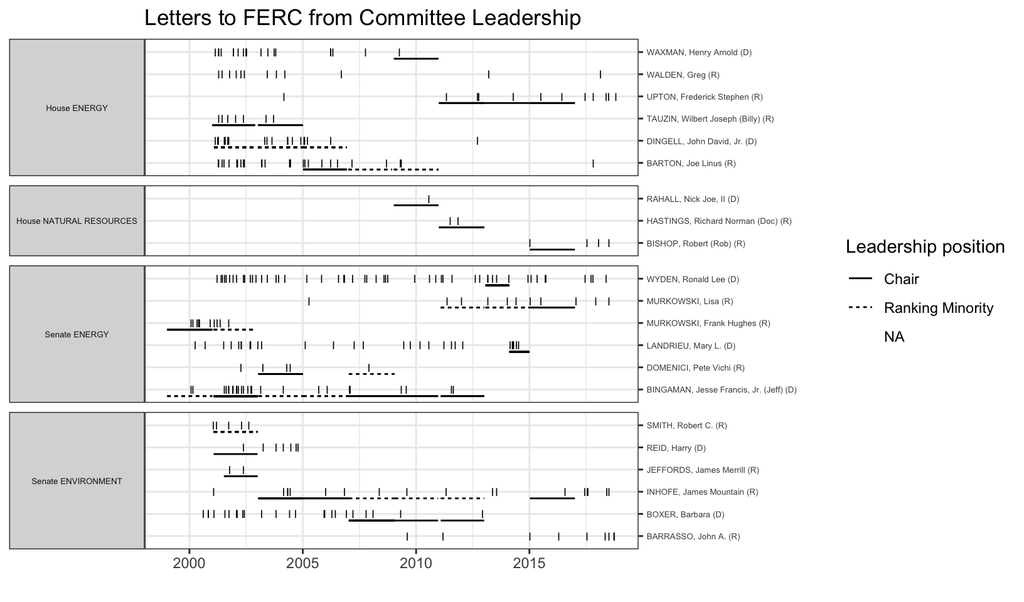

```r
dcommittees %>%
  mutate(chair = str_remove(chair,"[0-9]* |^NA "),
         committee = paste(chamber, committee))%>%
  dplyr::select(committee, position, chair, DATE, assigneddate, terminationdate) %>%
  distinct() %>%
  filter(str_detect(committee, "ENERGY$|ENVIRONMENT|NATURAL")) %>%
  mutate(position = ifelse(position == "Other", NA, position)) %>%
  #filter(# !is.na(position),chair_since_2007 == T) %>%
  drop_na(chair) %>%
  dplyr::select(DATE, chair, position, assigneddate, terminationdate, committee) %>%
  distinct() %>%
  ggplot() +
  geom_point(
    aes(x = DATE,
        y = chair),
    shape = 73,
    size=2
  ) +
  geom_segment(aes(y = chair, yend = chair,
                   x = assigneddate, xend = terminationdate,
                   linetype = factor(position)),
               position = position_nudge(y = -0.3)) +
  labs(title = paste("Letters to FERC from Committee Leadership"),
       y = "",
       x = "",
       linetype = "Leadership position") +
  scale_y_discrete(position = "right") +
  theme(
    strip.text.y = element_text(angle = 180, size = 5),
    # legend.title = element_blank(),
    axis.text.y = element_text(size=5),
    axis.text.x = element_text(angle = 0)
  ) +
  facet_grid(committee ~ ., scales = "free_y", space = "free_y", switch = "both")
```

## Many letters to FERC are cosigned

```r
#A rough under-estimate based on whether "et al" or "&" appears in the summary:

FERC_letters %>%
  filter(year>1999,
         year<2019) %>%
  group_by(ID) %>%
  top_n(1) %>%
  mutate(probably_cosigned = ifelse(str_detect(SUBJECT, "et al"), "et al",
                                 ifelse(str_detect(SUBJECT, "&"), "&", " neither"))) %>%
  group_by(year, probably_cosigned) %>%
  tally %>%
  ggplot() +
  aes(x = year, y = n, fill = probably_cosigned) +
  geom_col() +
  scale_fill_viridis_d(option = "C", end = .8)
```

[output not shown]

Cosigned letters identified by coders

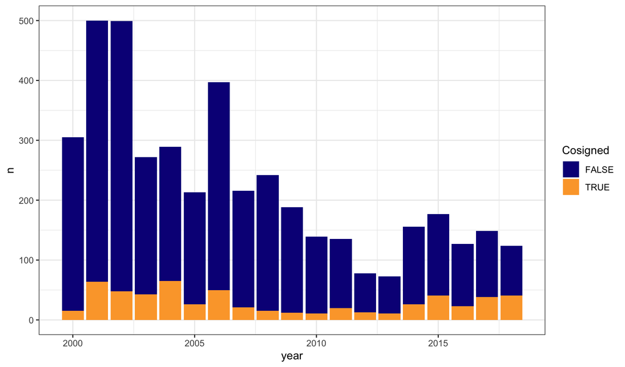

```r
FERC_letters %>%
  filter(!is.na(Freelancer),
         year>1999,
         year<2019) %>%
  mutate(Cosigned = ifelse(!is.na(Cosigned_House)|!is.na(Cosigned_Senate),
                                 T, F)) %>%
  group_by(year, Cosigned) %>%
  tally %>%
  ggplot() +
  aes(x = year, y = n, fill = Cosigned) +
  geom_col() +
  scale_fill_viridis_d(option = "C", end = .8)
```

# Companies

## Top companies in pro-business letters

```r
# Split out to one obs per member per letter per business
dcorps <- d %>%
  mutate(ProBusiness = ProBusiness %>% str_split(";")) %>%
  unnest(ProBusiness)

dcorps %<>% mutate(ProBusiness = ProBusiness %>%
                     str_replace("RTO",
                                 "Regional Transmission Organization") %>%
         str_remove_all(" Company.*| \\(.*| Inc.*| LLC.*| Energy.*") )%>%
  mutate(AntiBusiness = AntiBusiness %>%
           str_replace("RTO",
                       "Regional Transmission Organization") %>%
         str_remove_all(" Company.*| \\(.*| Inc.*| LLC.*| Energy.*") )

dcorps %>%
  filter(!is.na(ProBusiness),
         !str_detect(ProBusiness, "Regional Transmission Organization") ) %>%
  group_by(ProBusiness) %>%
  select(id, last_name, ProBusiness, ID) %>%
  distinct() %>%
  summarise( n = n() ,
             members = str_c(unique(last_name), collapse = "; "),
             ID = str_c(unique(ID), collapse = "; ")) %>%
  filter(n>quantile(n,.9))%>%
  arrange(-n) %>%
  knitr::kable()
```

| ProBusiness | n | members | ID |
| --- | --- | --- | --- |
| Duke | 28 | TILLIS; GRAHAM; CLYBURN; JONES; WILSON; FOXX; McHENRY; MULVANEY; DUNCAN; ELLMERS; GOWDY; HOLDING; HUDSON; MEADOWS; PITTENGER; RICE; ROUZER; WALKER; BURR; SCOTT; HELMS; BOUCHER; CLELAND; HOLLINGS | 20171208-0016; 20160523-0008; 20021008-0082; 20020830-0138; 20020617-0403; 20020102-0236; 20011019-0106; 20011011-0191; 20001229-0112 |
| Jordan Cove | 28 | GRAVES; MORAN; YODER; BARRASSO; GARDNER; BENNET; LEE; ENZI; HATCH; REID; SCHRADER; ROBERTS; LUMMIS; STEWART; BUCK; TIPTON; LAMBORN; COFFMAN; BISHOP; CHAFFETZ; LOVE | 20160519-0010; 20160419-0011; 20160419-0010; 20160413-0017; 20160411-0008; 20150402-0007; 20150115-0026 |
| Nevada Power | 22 | REID; BERKLEY; PORTER; HELLER; ENSIGN; GIBBONS; CANTWELL; SMITH; WYDEN; BOXER; FEINSTEIN | 20080626-0022; 20040702-0082; 20031120-0152; 20031105-0382 |
| Cheniere | 15 | FARENTHOLD; GREEN; LANDRIEU; ALEXANDER; BOUSTANY; MELANCON; SCALISE; CASSIDY; FLEMING; VITTER; CORNYN; INHOFE | 20140416-0025; 20100910-0040; 20050307-0011; 20050127-0022; 20050107-0022; 20050105-0146; 20040701-0068 |
| Union Electric | 14 | LUETKEMEYER; HARTZLER; CLEAVER; EMERSON; GRAVES; AKIN; LONG; CLAY; CARNAHAN; COSTELLO; SHIMKUS; SCHILLING; McCASKILL; BLUNT | 20110922-0009; 20110913-0012 |
| Grand River Dam Authority | 13 | INHOFE; MULLIN; BRIDENSTINE; LANKFORD | 20170809-0029; 20170807-0007; 20170802-0028; 20160826-0013; 20160803-0011; 20160729-0009; 20150804-0014 |
| PJM Interconnection | 13 | LAMB; GILLMOR; BOUCHER; GREENWOOD; PALLONE; DAVIS; BROWN; EHRLICH; SAWYER; PITTS; WYNN; STRICKLAND; DOYLE | 20180511-0007; 20020102-0046 |
| Allegheny | 12 | CANTWELL; SMITH; REID; WYDEN; BOXER; FEINSTEIN | 20031120-0152; 20031105-0382 |
| BP | 12 | CANTWELL; SMITH; REID; WYDEN; BOXER; FEINSTEIN | 20031120-0152; 20031105-0382 |
| Enron Power Marketing, | 12 | CANTWELL; SMITH; REID; WYDEN; BOXER; FEINSTEIN | 20031120-0152; 20031105-0382 |
| Morgan Stanley Capital Group | 12 | CANTWELL; SMITH; REID; WYDEN; BOXER; FEINSTEIN | 20031120-0152; 20031105-0382 |
| Sierra Pacific power | 12 | CANTWELL; SMITH; REID; WYDEN; BOXER; FEINSTEIN | 20031120-0152; 20031105-0382 |
| Denver Water | 10 | GARDNER; COFFMAN; PERLMUTTER; BENNET; DeGETTE | 20180622-0007; 20180411-0024; 20170404-0473 |
| Wisconsin’s business, | 10 | GREEN; OBEY; SENSENBRENNER; PETRI; KLECZKA; KIND; RYAN; BALDWIN; KOHL; FEINGOLD | 20040318-0001 |
| Florida Gas Transmission | 9 | SHELBY; CALLAHAN; SESSIONS | 20020117-0096; 20020102-0239; 20020102-0086 |
| California Independent System Operator | 8 | OSE | 20020204-0160; 20011221-0264; 20011221-0259; 20011019-0074; 20011011-0121; 20011005-0027; 20011005-0019; 20011005-0005 |
| Columbia Gas Transmission | 8 | MOONEY; STIVERS; JENKINS; CAPITO; McKINLEY | 20170615-0007; 20160506-0033; 20160315-0013; 20160119-0008; 20151103-0008; 20151103-0007 |
| Hydro Renewable | 8 | SHAHEEN; KUSTER; SHEA-PORTER; HASSAN | 20170621-0008; 20170404-0472 |
| ISO New England | 8 | REED; LEAHY; DODD; KERRY; LIEBERMAN; CHAFEE; JEFFORDS; KENNEDY | 20011019-0270 |
| South Carolins Electric and Gas | 8 | HOLLINGS; BROWN; CLYBURN; DeMINT; GRAHAM; SPENCE; SPRATT; THURMOND | 20010709-0250 |
| City of Hamilton | 7 | BROWN; DeWINE; VOINOVICH; SCHMIDT; BOEHNER | 20070507-0107; 20060810-0070; 20060802-0124; 20060725-0049; 20060714-0019 |
| PacifiCorp | 7 | HUFFMAN; BAIRD; WU; BLUMENAUER; HOOLEY; SMITH | 20161018-0008; 20011019-0492; 20000301-0117 |
| South Carolina Electric and Gas | 7 | HOLLINGS; THURMOND | 20030407-0284; 20020909-0280; 20011221-0114; 20011221-0112; 20011005-0209; 20011005-0110; 20010806-0608 |
| Woodland Pulp | 7 | KING; POLIQUIN; COLLINS | 20180227-0006; 20180209-0006; 20170912-0089 |
| Cheyenne Plains Gas Pipeline | 6 | CUBIN; THOMAS; ENZI; MUSGRAVE; ALLARD; MORAN | 20031120-0105; 20031030-0046; 20031010-0098; 20031010-0079 |
| Eastern Shore Natural Gas | 6 | CARPER; BLUNT ROCHESTER; COONS; CARNEY | 20171004-0007; 20160621-0020 |
| NRG McClain | 6 | NICKLES; INHOFE | 20040525-0113; 20040511-0052; 20040511-0051 |
| PPL Montana | 6 | BAUCUS; REHBERG; TESTER | 20071003-0168; 20071001-0199 |
| Spectra | 6 | LYNCH; ENGEL; GIBBS; JOHNSON; SIRES; GRIMM | 20160602-0013; 20151223-0021; 20150302-0021; 20131009-0016; 20120210-0001; 20120113-0002 |
| Ca]pine Corporation | 5 | LOFGREN; HONDA; MILLER; DOOLEY; TAUSCHER | 20040223-0049 |
| Congressional Black Caucus | 5 | JOHNSON; RANGEL; TOWNS; OWENS; MEEKS | 20020102-0089 |
| Idaho Power | 5 | CRAIG; CRAPO | 20030418-0059; 20011108-0110; 20010629-0178 |
| Kinder Morgan | 5 | SHAHEEN; KUSTER; GUINTA; AYOTTE; COCHRAN | 20150204-0011; 20141229-0090 |
| Magnolia LNG | 5 | BOUSTANY; CASSIDY; VITTER | 20160222-0007; 20160209-0024; 20160129-0008; 20150320-0022; 20150311-0010 |
| N/A | 5 | ISRAEL; KING; McCARTHY; ACKERMAN; BISHOP | 20040702-0083 |
| PPL Corporation | 5 | SPECTER; SANTORUM; TOOMEY | 20040206-0074; 20040202-0154; 20000811-0197 |
| Straight Creek Gathering, LP | 5 | ROGERS | 20061006-0193; 20061006-0191; 20060628-0147; 20060622-0084; 20060621-0127 |
| Tellurian | 5 | HIGGINS; SCALISE; CASSIDY; GREEN; GONZALEZ | 20181109-0007; 20181105-0012; 20181105-0011 |
| Woodstone Toronto Development, | 5 | GILMAN; SCHUMER | 20010712-0179; 20010709-0265; 20010622-0317; 20010622-0315; 20010621-0392 |

## Letters citing companies registered with FERC

Of the companies registered to interact with FERC, several appear in the letter texts. Here `company_short` is a shortened version a name that refrences several affiliated companies, each of which are registered separatly. *TO DO:*

- 1. Identify linked corporations for other top companies in the data using [this sheet](https://docs.google.com/spreadsheets/d/1FjZIuz8T97nczCbYskjT7-Hl6we6hoa6VndOnFmKDGU/edit#gid=0)
- 2. extract company contact persons and information from the FERC website.

```r
load(here("data", "DOE_FERC-corps.Rdata"))
FERC_corps %<>% ungroup() %>% group_by(company_short) %>% mutate(industry = str_c(unique(industry), collapse = ";")) %>% select(-company, -Fortune500) %>% distinct()

## Make a single string of short corp names
ferc_short <- unique(FERC_corps$company_short) %>%
  str_c(collapse = "|") %>%
  str_remove_all("||")

# bad string?
# str_detect("", ferc_short)

save(ferc_short, file = here("data/ferc_short.Rdata"))
```

## Pro-business letters

```r
dcorps %>%
  mutate(company_short = str_extract(ProBusiness, ferc_short)) %>%
  left_join(FERC_corps) %>%
  distinct() %>%
  group_by(company_short_refs) %>%
  select(ID, last_name, company_short, company_short_refs) %>%
  filter(company_short != "")%>%
  distinct() %>%
  summarise( n = n() ,
             company_short = str_c(unique(company_short), collapse = "; "),
             members = str_c(unique(last_name), collapse = "; "),
             ID = str_c(unique(ID), collapse = "; ")) %>%
  filter(n>quantile(n,.9))%>%
  select(company_short, n, everything()) %>%
  arrange(-n) %>%
  knitr::kable()
```

| company_short | n | company_short_refs | members | ID |
| --- | --- | --- | --- | --- |
| Duke | 31 | Duke Energy Carolinas, LLC; Duke Energy Indiana, LLC.; Duke Energy Progress, LLC.; Duke Energy Kentucky, Inc.; Duke Energy Ohio, Inc.; Duke Energy Carolinas, LLC; Duke Energy Corporation; Duke Energy … | TILLIS; GRAHAM; CLYBURN; JONES; WILSON; FOXX; McHENRY; MULVANEY; DUNCAN; ELLMERS; GOWDY; HOLDING; HUDSON; MEADOWS; PITTENGER; RICE; ROUZER; WALKER; BURR; SCOTT; TAYLOR; HELMS; BOUCHER; CLELAND; HOLLIN… | 20171208-0016; 20160523-0008; 20141022-4015; 20050808-0081; 20060508-0029(partial); 20021008-0082; 20020830-0138; 20020617-0403; 20020102-0236; 20011019-0106; 20011011-0191; 20001229-0112 |
| Nevada Power | 24 | Nevada Power Company | HELLER; REID; BERKLEY; PORTER; ENSIGN; GIBBONS; CANTWELL; SMITH; WYDEN; BOXER; FEINSTEIN | 20130807-0016; 20130725-0017; 20080626-0022; 20040702-0082; 20031120-0152; 20031105-0382 |
| Union Electric | 14 | Union Electric Company d/b/a Ameren Missouri; Union Electric Company d/b/a Ameren Missouri | LUETKEMEYER; HARTZLER; CLEAVER; EMERSON; GRAVES; AKIN; LONG; CLAY; CARNAHAN; COSTELLO; SHIMKUS; SCHILLING; McCASKILL; BLUNT | 20110922-0009; 20110913-0012 |
| PJM Interconnection | 13 | PJM Interconnection, L.L.C. | LAMB; GILLMOR; BOUCHER; GREENWOOD; PALLONE; DAVIS; BROWN; EHRLICH; SAWYER; PITTS; WYNN; STRICKLAND; DOYLE | 20180511-0007; 20020102-0046 |
| Allegheny | 12 | Allegheny Energy Service Corporation; Allegheny Energy Supply Company, LLC; Allegheny Energy Supply Company, LLC; Allegheny Energy Supply Units 3, 4, & 5, LLC | CANTWELL; SMITH; REID; WYDEN; BOXER; FEINSTEIN | 20031120-0152; 20031105-0382 |
| BP | 12 | BP Pipelines (Alaska) Inc.; BP Pipelines (North America) Inc.; BP Energy Company; BP Energy Company | CANTWELL; SMITH; REID; WYDEN; BOXER; FEINSTEIN | 20031120-0152; 20031105-0382 |
| Enron Power Marketing | 12 | Enron Power Marketing, Inc. | CANTWELL; SMITH; REID; WYDEN; BOXER; FEINSTEIN | 20031120-0152; 20031105-0382 |
| ISO New England | 12 | ISO New England Inc. | REED; LEAHY; DODD; KERRY; LIEBERMAN; CHAFEE; JEFFORDS; KENNEDY; SNOWE; BALDACCI; ALLEN; COLLINS | 20011019-0270; 20010111-0319 |
| Morgan Stanley Capital Group | 12 | Morgan Stanley Capital Group Inc. | CANTWELL; SMITH; REID; WYDEN; BOXER; FEINSTEIN | 20031120-0152; 20031105-0382 |
| Columbia Gas Transmission | 11 | Columbia Gas Transmission, LLC | CAPITO; MOONEY; STIVERS; JENKINS; McKINLEY; BOUCHER | 20171129-0011; 20171012-0012; 20170615-0007; 20160506-0033; 20160315-0013; 20160119-0008; 20151103-0008; 20151103-0007; 20040305-0198 |

```r
## Longer list with company full names
# d %>%
#   mutate(company_short = str_extract(ProBusiness, ferc_short)) %>%
#   drop_na(company_short) %>%
#   mutate(members = paste(CongressPerson, Cosigned_House, Cosigned_Senate, sep = ";")) %>%
#   mutate(members = str_remove_all(members, ";NA")) %>%
#   group_by(company_short) %>%
#   mutate(members = str_c(unique(members), collapse = ";")) %>%
#   select(company_short, members) %>%  distinct() %>%
#   left_join(FERC_corps) %>% distinct() %>%
#   knitr::kable(caption = "Pro Businesses matching those registered with FERC")
```

## Anti-business letters

```r
dcorps %>%
  mutate(company_short = str_extract(AntiBusiness, ferc_short)) %>%
  left_join(FERC_corps) %>%
  distinct() %>%
  group_by(company_short_refs) %>%
  select(ID, last_name, company_short, company_short_refs) %>%
  filter(company_short != "")%>%
  distinct() %>%
  summarise( n = n() ,
             company_short = str_c(unique(company_short), collapse = "; "),
             members = str_c(unique(last_name), collapse = "; "),
             ID = str_c(unique(ID), collapse = "; ")) %>%
  filter(n>quantile(n,.9))%>%
  select(company_short, n, everything()) %>%
  arrange(-n) %>%
  knitr::kable()
```

| company_short | n | company_short_refs | members | ID |
| --- | --- | --- | --- | --- |
| Dominion | 138 | Dominion Energy Cove Point LNG, LP; Dominion Energy Questar Pipeline, LLC; Dominion Energy Overthrust Pipeline, LLC; Dominion Energy Transmission, Inc; Dominion Energy Cove Point LNG, LP; Dominion Ene… | VAN HOLLEN; GOODLATTE; KAINE; FORBES; GIBSON; HANNA; COCHRAN; MIKULSKI; CARDIN; WYNN; HOYER; SARBANES; WARNER; ROCKEFELLER; RAHALL; BYRD; ALLEN; GOODE; CANTOR; BOUCHER | 20170918-0007; 20170802-0031; 20170609-0037; 20160406-0022; 20150826-0036; 20150826-0031; 20150311-0008; 20150311-0007; 20150303-0016; 20150130-0007; 20150126-0033; 20150115-0028; 20141229-0090; 20140… |
| ISO New England | 73 | ISO New England Inc. | DODD; SHAYS; SIMMONS; JOHNSON; DeLAURO; LARSON; LIEBERMAN; MARKEY; LANGEVIN; FRANK; LYNCH; SANDERS; MICHAUD; TIERNEY; CAPUANO; NEAL; MEEHAN; McGOVERN; ALLEN; KENNEDY; KERRY; JEFFORDS; REED; COLLINS; S… | 20050822-0110; 20050810-0209; 20050719-0104; 20050719-0103; 20050711-0239; 20050711-0238; 20010329-0009; 20010329-0003; 20010329-0002; 20010329-0005 |
| Columbia Gas Transmission | 45 | Columbia Gas Transmission, LLC | CARDIN; HOYER; RUPPERSBERGER; CUMMINGS; SARBANES; MIKULSKI; BROWN; VOINOVICH; JORDAN; KELLY; BYRD; LOWEY; GILMAN; SCHUMER; CLINTON; JOHNSON; RANGEL; TOWNS; OWENS; MEEKS | 20130124-0015; 20090908-0068; 20090812-0016; 20090527-0015; 20090508-0077; 20120712-0003; 20081222-0201; 20081113-0083; 20081001-0013; 20081001-0012; 20080731-0190; 20080619-0125; 20050421-0116; 20020… |
| Duke | 38 | Duke Energy Carolinas, LLC; Duke Energy Indiana, LLC.; Duke Energy Progress, LLC.; Duke Energy Kentucky, Inc.; Duke Energy Ohio, Inc.; Duke Energy Carolinas, LLC; Duke Energy Corporation; Duke Energy … | McHENRY; DUNCAN; MYRICK; HAGAN; DOLE; PLATTS; DeMINT; TAYLOR; GRAHAM; SPRATT; COCHRAN; GOODE; WARNER; FEINSTEIN; FRIST; LUCAS; ALLEN; CORZINE; SKEEN; BOUCHER | 20170508-0011(partial); 20151201-0086(partial); 20101119-0024; 20100804-0015; 20100525-0030; 20100525-0021; 20110321-0050; 20110302-0023; 20080522-0130; 20080522-0129; 20071231-0079; 20061011-0271(par… |
| Transcontinental | 37 | Transcontinental Gas Pipeline Company, LLC | PALLONE; BOOKER; MacARTHUR; HOLT; SPECTER; PITTS; GERLACH; CASEY; WEBB; WOLF; SMITH; LAUTENBERG; CORZINE; TORRICELLI; TOOMEY; HELMS; EDWARDS; MYRICK; WATT | 20180516-0006; 20180326-0009; 20170829-0016; 20160926-0008; 20160301-0012; 20130625-0010; 20080929-0011; 20080919-0131; 20080820-0006; 20080310-0104; 20070402-0017; 20070312-0037; 20070308-0146; 20050… |
| Tennessee Gas Pipeline | 30 | Tennessee Gas Pipeline Company, L.L.C. | MARKEY; WARREN; NEAL; COOPER; McCONNELL; KUSTER; AYOTTE; SCHUMER; GILLIBRAND; TSONGAS; LARSON; TONKO; GIBSON; McGOVERN; CARNEY; CASEY; SUNUNU; SMITH; SANTORUM | 20180111-0007; 20170428-0009; 20170421-0006; 20161014-0011; 20160926-0009; 20160624-0017; 20160510-0011; 20160510-0010; 20160405-0074; 20160309-0119; 20160212-0008; 20151020-0012; 20150908-0010; 20150… |
| Florida Gas Transmission | 29 | Florida Gas Transmission Company, LLC | NELSON; GRAHAM; CLINTON; BILIRAKIS; KELLER; THURMAN | 20100910-0033(partial); 20100910-0029(partial); 20020813-0006; 20020813-0004; 20020716-0148; 20020716-0147; 20020716-0143; 20020716-0139; 20020716-0138; 20020716-0136; 20020702-0062; 20020521-0106; 20… |
| Ameren | 26 | Ameren Corporation; Ameren Energy Medina Valley Cogen, L.L.C. | BLUNT; McCASKILL; LUETKEMEYER; HULSHOF; CLAY; MOORE; BROWNBACK; ROBERTS; SKELTON; TALENT; BOND | 20180216-0016; 20101006-0005(partial); 20110315-0013(partial); 20080407-0122; 20070905-0024; 20060518-0038; 20060518-0005(partial); 20060517-0319(partial); 20060517-0317(partial); 20060517-0316; 20060… |
| Spectra | 26 | Spectra Energy Transmission, LLC | LYNCH; MARKEY; WARREN; LOWEY; SCHUMER; GILLIBRAND; CHAMBLISS; SIRES; PLATTS; CASEY; SHUSTER; KERRY | 20180223-0007; 20170405-0192; 20170201-0010; 20170109-0048; 20161216-0007; 20161004-0075; 20160805-0007; 20160729-0014; 20160614-0011; 20160601-0006; 20150625-0023; 20150408-0006; 20140424-0016; 20100… |
| California Independent System Operator | 23 | California Independent System Operator Corporation, The | RADANOVICH; MATSUI; MURRAY; DICKS; McDERMOTT; SMITH; BAIRD; INSLEE; LARSEN; FARR; DeFAZIO; WU; CAPPS; HOOLEY; CONDIT; FILNER | 20081001-0002; 20080919-0118; 20080820-0004; 20011018-0036; 20010621-0007 |
| San Diego Gas & Electric | 23 | San Diego Gas & Electric Company | ESHOO; WAXMAN; LOFGREN; CAPPS; WATERS; MATSUI; LANTOS; BERMAN; WATSON; CARDOZA; SHERMAN; DAVIS; ROYBAL-ALLARD; HARMAN; SCHIFF; TAUSCHER; SANCHEZ; MILLENDER-McDONALD; HONDA; FARR; LEE; BACA; NAPOLITANO | 20031007-0254 |
| Appalachian Power | 19 | Appalachian Power Company | GARRETT; KAINE; PERRIELLO; WARNER; GRIFFITH; ROE; GOODE; ALLEN | 20170613-4008(partial); 20170217-0007; 20100910-0037; 20100910-0031(partial); 20100525-0023; 20091123-0150; 20091013-0008; 20110719-0003; 20110218-0028(partial); 20080310-0107; 20050912-0255; 20050912… |

```r
## Longer list with company full names
# d %>%
#   mutate(company_short = str_extract(AntiBusiness, ferc_short)) %>%
#   drop_na(company_short) %>%
#   mutate(members = paste(CongressPerson, Cosigned_House, Cosigned_Senate, sep = ";")) %>%
#   mutate(members = str_remove_all(members, ";NA")) %>%
#   group_by(company_short) %>%
#   mutate(members = str_c(unique(members), collapse = ";")) %>%
#   select(company_short, members) %>%  distinct() %>%
#   left_join(FERC_corps) %>% distinct() %>%
#   knitr::kable(caption = "Anti Businesses matching those registered with FERC")
```

## Company lookup table

Clean companies names extracted from letters and create shortened name that is more likely to be found in other datasets (like done with FERC-registerd companies above).

```r
# Split out to one obs per member per letter per business
dcorps <- d %>%
  select(ID, bioname, ProBusiness, AntiBusiness, ProProject, AntiProject) %>%
  gather(value = "company", key = "position", -ID, -bioname) %>%
  mutate(company = company %>% str_split(";")) %>%
  unnest(company) %>% distinct()

dcorps %<>% mutate(company = company %>%
                     str_replace("RTO",
                                 "Regional Transmission Organization") %>%
         str_remove_all(" Company.*| \\(.*| Inc.*| LLC.*| Energy.*") )

dcorps$company %<>%
  trimws()  # trim white space before and after company names

dcorps %<>%   filter(nchar(company)>1) %>%# drop names less than 1 character
  distinct() # drop duplicates

## For matching, remove endings like ", Inc." etc.
trim <- function(d){
d %>%
  str_remove_all("Village of |\\(.*|,.*| -.*|^Proposed | Pipe.*| pipe.*| project$| Proiects$| Company.*| Comnany| Corp.*| Co$| Co.$| Energy$| energy$| power$| Power marketing$| Holdings.*| Group$| Gas$| Project.*| LLC| L.L.C.|  L.P.|^The | Inc.| L.P.| Ltd.| LP| Limited Partnership| Limited Liability|  Facility| Transportation and Storage| Storage and Transportation") %>%
  str_remove_all("^, ") %>%
  trimws()  # filter out names less than 2 characters
}



dcorps$company_short <- trim(dcorps$company) %>% trim()
```

Problem company names that may need to be fixed (e.g. to remove special characters or spell out abbreviated name)

```r
# Problem Names
dcorps %>% filter(nchar(company_short)<2) %>% knitr::kable()
```

| ID | bioname | position | company | company_short |
| --- | --- | --- | --- | --- |

```r
dcorps %<>% filter(nchar(company_short)>1)
```

Identify short names by hand:

```r
## Correct over-trimmed names
dcorps %<>%
  mutate(company_short = ifelse(company == "Columbia Energy Power Marketing Corporation", "Columbia Energy", company_short))%>%
  mutate(company_short = ifelse(company == "Michigan Energy Exchange, LLC", "Michigan Energy", company_short))%>%
  mutate(company_short = ifelse(company == "Midwest Energy, Inc.", "Midwest Energy", company_short))%>%
  mutate(company_short = ifelse(company == "Northwest Pipeline LLC", "Northwest Pipeline", company_short))%>%
  mutate(company_short = ifelse( str_detect(company, "^Dominion"),
                                 "Dominion", company_short))%>%
  mutate(company_short = ifelse(company == "Peak Energy, Inc.", "Peak Energy", company_short))%>%
  mutate(company_short = ifelse(company == "Public Service Company of New Mexico", "Public Service Company of New Mexico", company_short))%>%
  mutate(company_short = ifelse(company == "Salt Lake Energy Systems, LLC", "Salt Lake Energy", company_short))%>%
  mutate(company_short = ifelse(company == "Natural Gas Pipeline Company of America", "Natural Gas Pipeline Company of America", company_short))%>%
  mutate(company_short = ifelse(company == "Natural Gas Trading Corporation", "Natural Gas Trading Corporation", company_short))%>%
  mutate(company_short = ifelse(company == "Energy, USA-TPC Corp.", "TPC", company_short))%>%
  mutate(company_short = ifelse(company == "New Energy Partners, L.L.C.", "New Energy Partners", company_short))%>%
  mutate(company_short = ifelse(company == "New Energy Service, LLC", "New Energy Service", company_short))%>%
  mutate(company_short = ifelse(company == "North Energy Associates, A Limited Partnership", "North Energy Associates", company_short))%>%
  mutate(company_short = ifelse(company == "Pipeline Company LLC", "Pipeline Company LLC", company_short))%>%
  mutate(company_short = ifelse(company == "Express Pipeline LLC", "Express Pipeline LLC", company_short))%>%
  mutate(company_short = ifelse(company == "American Energy Savings, Inc.", "American Energy Savings", company_short))%>%
  mutate(company_short = ifelse(company == "Electric Energy, Inc.", "Electric Energy, Inc.", company_short))%>%
  mutate(company_short = ifelse(company == "System Energy Resources, Inc., Llano Estacado Wind, LLC, System Energy Resources, Inc., Northern Iowa Windpower, LLC, and RS Cogen, L.L.C.", "System Energy Resources", company_short))%>%
  mutate(company_short = ifelse(company == "Public Service Company of Colorado", "Public Service Company of Colorado", company_short))%>%
  mutate(company_short = ifelse(company == "Southern Company Services, Inc.", "Southern Company", company_short))%>%
  mutate(company_short = ifelse(company == "International Energy Consultants", "International Energy Consultants", company_short))%>%
  mutate(company_short = ifelse(company == "Jackson Pipeline Company", "Jackson Pipeline", company_short))%>%
  mutate(company_short = ifelse(company == "Southern Energy California", "Southern Energy California", company_short))%>%
  mutate(company_short = ifelse(company == "Tennessee Gas Pipeline Company, L.L.C.", "Tennessee Gas Pipeline", company_short))%>%
  mutate(company_short = ifelse(company == "Select Energy New York, Inc.", "Select Energy New York", company_short))%>%
  mutate(company_short = ifelse(company == "Inland Corporation", "Inland Corporation", company_short))%>%
  mutate(company_short = ifelse(company == "Advanced Energy Systems, Inc.", "Advanced Energy Systems", company_short))%>%
  mutate(company_short = ifelse(company == "Consumers Energy Company", "Consumers Energy Company", company_short))%>%
  mutate(company_short = ifelse(company == "Boston Energy Trading and Marketing LLC", "Boston Energy", company_short))%>%
  mutate(company_short = ifelse(company == "Complete Energy Services, Inc.", "Complete Energy Services", company_short))%>%
  mutate(company_short = ifelse(company == "El Paso Energy Intrastate, L.P.", "El Paso Energy", company_short))%>%
  mutate(company_short = ifelse(company == "Houston Pipe Line Company LP", "Houston Pipe Line", company_short))%>%
  mutate(company_short = ifelse(company == "North American Energy, Inc.", "North American Energy", company_short))%>%
  mutate(company_short = ifelse(company == "Spokane Energy, LLC", "Spokane Energy", company_short))%>%
  mutate(company_short = ifelse(company == "Salem Energy Systems, LLC", "Salem Energy", company_short))%>%
  mutate(company_short = ifelse(company_short == "Direct", "Direct Energy", company_short))%>%
  mutate(company_short = ifelse(company_short == "DC", "DC Energy", company_short))%>%
  mutate(company_short = ifelse(company_short == "PS", "PS Energy Group", company_short)) %>%
  mutate(company_short = ifelse(company_short == "Coastal", "Coastal Pipeline", company_short)) %>%
  mutate(company_short = ifelse(company_short == "CT", "CT Corporation", company_short)) %>%
  mutate(company_short = ifelse(company_short == "Forest", "Forest Pipeline", company_short)) %>%
  mutate(company_short = ifelse(company_short == "Minnesota", "Minnesota Pipe Line", company_short)) %>%
  mutate(company_short = ifelse(company_short == "NW", "NW Pipeline", company_short)) %>%
  mutate(company_short = ifelse(company_short == "Ohio River", "Ohio River Pipe Line", company_short)) %>%
  mutate(company_short = ifelse(company_short == "Rio Grande", "Rio Grande Pipeline", company_short)) %>%
  mutate(company_short = ifelse(company_short == "Plains", "Plains Pipeline", company_short)) %>%
  mutate(company_short = ifelse(company_short == "Portland", "Portland Pipe Line", company_short)) %>%
  mutate(company_short = ifelse(company_short == "AP", "AP Holdings", company_short)) %>%
  mutate(company_short = ifelse(company_short == "Ohio River", "Ohio River Pipe Line", company_short)) %>%
  mutate(company_short = ifelse(company_short == "Boundary", "Boundary Gas", company_short)) %>%
  mutate(company_short = ifelse(company_short == "Columbia", "Columbia Energy", company_short)) %>%
  mutate(company_short = ifelse(company_short == "Independence", "Independence Energy Group", company_short)) %>%
  mutate(company_short = ifelse(company_short == "Lakeside", "Lakeside Energy", company_short)) %>%
  mutate(company_short = ifelse(company_short == "Mitchell", "Mitchell Energy", company_short)) %>%
  mutate(company_short = ifelse(company_short == "Stream", "Stream Energy", company_short))%>%
  mutate(company_short = ifelse(str_detect(company, "^Northwest Pipeline"), "Northwest Pipeline", company_short))%>%
  mutate(company_short = ifelse(str_detect(company, "^Tennessee Gas"), "Tennessee Gas", company_short))%>%
  mutate(company_short = ifelse(str_detect(company, "Juniper Hills Country Club"), "Juniper Hills Country Club", company_short))%>%
    mutate(company_short = ifelse(str_detect(company, regex("Columbia Gas", ignore_case = T)), "Columbia Gas", company_short))%>%
  mutate(company_short = ifelse(str_detect(company, regex("Algonquin", ignore_case = T)), "Algonquin", company_short))%>%
    mutate(company_short = ifelse(str_detect(company, regex("Spectra", ignore_case = T)), "Spectra", company_short))%>%
  mutate(company_short = ifelse(str_detect(company, regex("Jordan Cove", ignore_case = T)), "Jordan Cove", company_short))%>%
    mutate(company_short = ifelse(str_detect(company, regex("Enron", ignore_case = T)), "Enron", company_short))%>%
     mutate(company_short = ifelse(str_detect(company, regex("Nexus", ignore_case = T)), "Nexus", company_short))%>%

  mutate(company_short = ifelse(company == "Express Pipeline", "Express Pipeline", company_short))%>%
  mutate(company_short = ifelse(company %in% c("American Energy", "American energy"), "American Energy", company_short))%>%
  mutate(company_short = ifelse(str_detect(company, "PG&E|Pacific Gas & Electric|Pacific Gas and Electric"), "PG&E", company_short)) %>%
  mutate(company_short = ifelse(company %in% c("Pacific Corp.", "Pacific Corps"), "PacifiCorp", company_short)) %>%
  mutate(company_short = ifelse(company_short == "AI", "AI Energy", company_short)) %>%
  mutate(company_short = ifelse(company_short %in% c("N/A","Na","NO",
                                                     "Clean Water Act","Na",
                                                     "Energy", "West", "NA",
                                                     "Central", "Power", "Natural",
                                                     "Consumers", "LNG"),
         "NOT A COMPANY?",  company_short))
```

Short company names, e.g. “Duke” may refer to many affiliated companies. The variable `company_short_refs` lists these affiliated companies.

```r
#FIXME
# ADD company_short_refs
dcorps %<>%
  group_by(company_short) %>%
  mutate(company_short_refs = str_c(unique(company), collapse = "; ")) %>% ungroup()
```

Look for problematic company names. For example what should we do with companies that are just state, region, or city names? (e.g. El Paso Corporation, Tennessee Gas, American Energy, Southern, etc.)

```r
## Inspect over-trimmed company names
dcorps %>% filter(company_short %in% c("", "NA", "na", "Na", "LLC", "Energy", "Pipeline", "Natural", "North", "New", "Express", "gas", "American", "Electric", "System", "Direct", "DC", "PS", "CT", "Forest", "International", "Tennessee", "Salt Lake", "Lakeside", "NW", "Jackson", "Public Service", "Peak", "Independence", "Select", "Portland", "Michigan", "Boundary", "Coastal", "Minnesota", "Midwest", "Northeast", "Columbia", "Plains", "Stream", "Mitchell", "AP", "Southern", "Ohio River", "Northwest", "Rio Grande", "AI", "Transportation", "12/20/2018", "Salem", "Boston", "Spokane", "El Paso", "Houston", "North American", "Consumers", "Advanced", "Complete", "Inland", "Limited Partnership", "Sun", "RTO", "Pacific", "LNG")) %>% select(company_short, company_short_refs, ID) %>%
  group_by(company_short) %>%
  summarise(company_short_refs = str_c(unique(company_short_refs), collapse = "; "),
            IDs = str_c(unique(ID), collapse = "; ")) %>%
  distinct() %>% knitr::kable()
```

| company_short | company_short_refs | IDs |
| --- | --- | --- |
| El Paso | El Paso Corporation; El Paso; El Paso Gas Co.; El Paso Pipeline | 20040728-0251; 20040723-0183; 20031010-0098; 20040513-0093; 20040511-0203; 20021028-0230; 20020702-0066; 20020509-0108 |
| New | New pipeline and storage wells in Rankin County | 20050531-0064 |
| Northeast | Northeast | 20150402-0009; 20160105-0021; 20150518-0133; 20150430-0038; 20150204-0011; 20160510-0011; 20160510-0010; 20160428-0006; 20160405-0074; 20160401-0060; 20160329-0033; 20160325-0007; 20160309-0119; 20160… |
| Pipeline | Pipeline | 20000725-0151 |
| Public Service | Public Service | 20000828-0096 |
| Southern | Southern | 20060530-0194; 20060406-0079; 20060406-0078; 20010712-0179; 20010709-0593; 20010709-0265; 20010622-0317; 20010622-0315; 20010621-0392; 20010620-0154; 20010402-0103 |
| Sun | Sun Pipe Line Co; Sun Pipe Line Co.right-of-way line project | 20020930-0231 |

```r
##  did I acidentally delete everything before a comma?
# dcorps %>% filter(str_detect(company_short, ","))
```

## Top 10 cited parent companies pro or con

```r
# top corps
topcorps <- dcorps %>% group_by(company_short) %>% tally() %>% arrange(-n) %>% top_n(10)

filter(dcorps, company_short %in% topcorps$company_short) %>%
  group_by(company_short) %>%
  summarise(#IDs = str_c(unique(ID), collapse = "; ")
    company_short_refs = str_c(unique(company_short_refs), collapse = "; ") ) %>%
  distinct() %>% knitr::kable()
```

[output not shown]

```r
# corps with short names
shortcorps <- dcorps %>%
  ungroup() %>%
  group_by(company_short) %>%
  tally() %>%
  arrange(nchar(company_short)) %>%
  mutate(nchar = nchar(company_short))%>%
  top_n(10, -nchar) %>% distinct()

filter(dcorps, company_short %in% shortcorps$company_short) %>%
  group_by(company_short) %>%
  summarise(company_short_refs = str_c(unique(company_short_refs), collapse = "; "),
            IDs = str_c(unique(ID), collapse = "; ")) %>%
  distinct() %>% knitr::kable()
```

| company_short | company_short_refs | IDs |
| --- | --- | --- |
| AEP | AEP; AEP Project | 20080215-0204; 20020222-0486 |
| AES | AES; AES Corporation; AES Corp | 20090128-0141; 20060425-0178; 20060406-0110; 20060310-0063; 20060301-0499; 20020320-0528 |
| AIM | AIM Project | 20150625-0019; 20180926-0012 |
| ANR | ANR Pipeline Project; ANR Pipeline | 20020301-0083; 20020215-0113; 20010801-0265; 20010709-0365; 20010627-0096 |
| B-G | B-G Project | 20180326-0008; 20180322-5062 |
| BG | BG Group | 20140425-0014 |
| BP | BP | 20031120-0152; 20031105-0382 |
| C&X | C&X Gas | 20050208-0316 |
| CMS | CMS | 20010328-0460 |
| DTE | DTE | 20171020-0015; 20160908-0008 |
| DWR | DWR | 20180424-0007 |
| EQT | EQT | 20150729-0052 |
| FGT | FGT | 20010806-0448; 20010806-0432; 20010726-0102; 20010726-0100; 20010726-0099 |
| FPL | FPL | 20100308-0001; 20080522-0128 |
| Gas | Gas Pipeline Project | 20030721-0040 |
| GB | GB | 20160115-0006; 20160111-0039; 20140619-0006 |
| GE | GE | 20151230-0012 |
| JDJ | JDJ | 20020509-0176; 20020403-0704 |
| JW | JW Holdings | 20030801-0191 |
| M&J | M&J Holdings, | 20031030-0017 |
| MVP | MVP | 20160921-0011 |
| NED | NED | 20150311-0006 |
| New | New pipeline and storage wells in Rankin County | 20050531-0064 |
| NV | NV | 20130807-0016; 20130725-0017 |
| PJM | PJM | 20180622-0008; 20150928-0009 |
| PNM | PNM | 20011018-0299 |
| PPL | PPL Corporation; PPL; PPL, Montana | 20040206-0074; 20040202-0154; 20000811-0197; 20091218-4021; 20091209-0036 |
| REX | REX; REX Pipeline | 20080813-0285; 20080616-0014; 20080611-0084(partial); 20080522-0150; 20080522-0149; 20080207-0113; 20080102-0300; 20090918-0094; 20080602-0021 |
| SCG | SCG Pipeline | 20020506-0070; 20020509-0112 |
| SMP | SMP project | 20000828-0115 |
| Sun | Sun Pipe Line Co; Sun Pipe Line Co.right-of-way line project | 20020930-0231 |
| VLP | VLP Project | 20000331-0104 |
| WPS | WPS | 20150824-0026 |

```r
#dcorps %>% filter(!position %in% c("ProProject", "AntiProject")) %>%  group_by(company_short) %>% tally() %>% arrange(-nchar(company_short))  %>% top_n(20) %>% knitr::kable()
```

[This sheet](https://docs.google.com/spreadsheets/d/1-QNgeiMnH97jN_0vCqFKEGEB5Ztpito3iRsqK8jN3Cs/edit#gid=0) tracks non-companies in our data.

```r
library(googlesheets)
library(httpuv)

# log in to google drive
gs_auth()

notcorps <- gs_title("not_companies") %>% gs_read()


dcorps %<>% ungroup() %>%
  mutate(company_short = ifelse(company_short %in% notcorps$not_companies,
                                "NOT A COMPANY?", company_short) )

#FIXME
# ADD company_short_refs again after corrections
dcorps %<>%
  group_by(company_short) %>%
  mutate(company_short_refs = str_c(unique(company), collapse = "; ")) %>% ungroup()

dcorps %>%
  filter(position %in% c("ProProject", "ProBusiness")) %>%
  select(ID, company_short, company)%>%
  group_by(company_short) %>%
  distinct() %>%
  add_count() %>%
  arrange(-n) %>%
  #write_csv(path = here("FERC/ProBusinesses.csv"))
  head()

# sum(is.na(unique(dcorps$company_short)))

## Make a single string of short corp names
dcorp_short <- unique(dcorps$company_short) %>%
  str_c(collapse = "|") %>%
  str_remove_all("||")

# bad string?
# str_detect("", dcorp_short)


save(dcorp_short, file = here("data/dcorp_short.Rdata"))
save(dcorps, file = here("data/dcorps.Rdata"))

# notcorps$company
```

Drop non-company observations

```r
notcorps <- filter(dcorps, company_short == "NOT A COMPANY?")


sum(!is.na(d$ProBusiness))
```

```
## [1] 948
```

```r
d %<>%
  mutate(ProBusiness = ifelse(ProBusiness %in% notcorps$company, NA, ProBusiness)) %>%
  mutate(ProProject = ifelse(ProProject %in% notcorps$company, NA, ProProject))

sum(!is.na(d$ProBusiness))
```

```
## [1] 943
```

# PAC Contributions from the Energy Sector

Using CRP industry codes for PACs and DIME contribution matrix, sum up sector-level contributions by memeber per cycle, matching a congress with the cycle when it was elected (e.g. 116th congress = 2018 cycle).

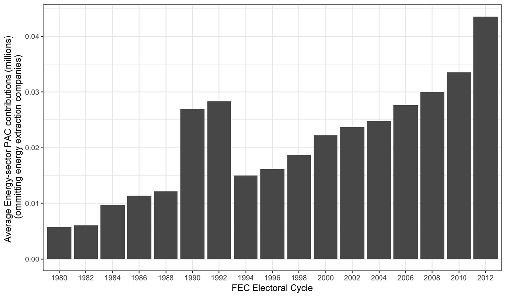

```r
library(tidyverse)
library(dplyr)
# load data
load(here("data/contrib_total.rds"))

contrib_total %<>%
    mutate(cycle = str_sub(ICPSR, -4)) %>%
  filter(cycle < 2014) %>% distinct()


# inspect coverage
contrib_total %>%
  group_by(cycle, ICPSR) %>%
  summarise(total = sum(value, na.rm = TRUE)/1000000) %>%
  ungroup() %>%
  group_by(cycle) %>%
  summarise(mean = mean(total)) %>%
  ggplot() +
  aes(x = factor(cycle), y = mean) +
  geom_col() +
  labs(y = "Average Energy-sector PAC contributions (millions) \n (ommitting energy extraction companies)",
       x = "FEC Electoral Cycle")
```

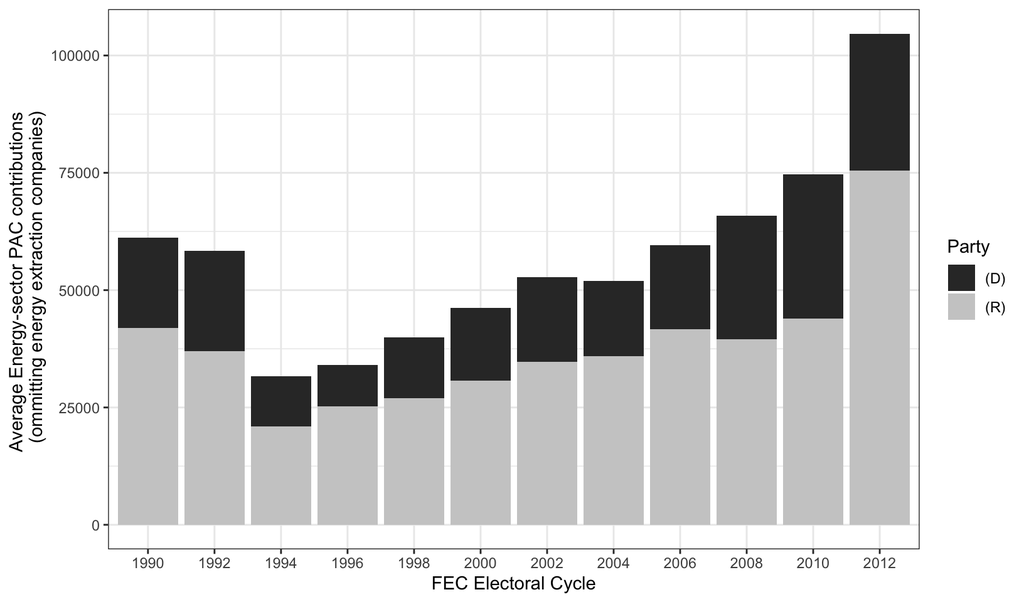

```r
# merge with letters data, d
contrib_total %<>%
  dplyr::rename(icpsryear = ICPSR,
         PAC_contributions = value) %>%
  mutate(cycle = str_sub(icpsryear, -4),
         icpsr = as.numeric(str_remove(icpsryear, cycle)),
         cycle = as.numeric(cycle)) %>%
  filter(cycle > 1989) %>%
  left_join(d %>% dplyr::select(icpsr, name_state, party) %>% distinct())

# inspect for coverage
contrib_total %>%
  drop_na(party) %>%
  group_by(cycle, party, icpsr) %>%
  summarise(total = sum(PAC_contributions, na.rm = TRUE)) %>%
  ungroup() %>%
  group_by(cycle, party) %>%
  summarise(mean = mean(total)) %>%
  ggplot() +
  aes(x = factor(cycle), y = mean, fill = party) +
  geom_col() +
  scale_fill_grey() +
  labs(y = "Average Energy-sector PAC contributions \n (ommitting energy extraction companies)",
       fill = "Party",
       x = "FEC Electoral Cycle")
```

```r
letters_money <- d %>%
  #FIXME
  filter(cycle <2014) %>%
  filter(!is.na(ProBusiness)|!is.na(ProProject))%>%
  #filter(Type %in% c("Corp. Constituent", "Policy")) %>%
  group_by(icpsryear, cycle, name_state, party, congress, icpsr, chamber, oversight_committee) %>%
  summarise(ProBusiness_Letters = n()) %>%
  #FIXME
  filter(cycle <2014) %>%
  distinct()

nrow(letters_money)
```

```
## [1] 700
```

```r
# join letters and DIME data by ICPSR, adding a sum of sector PAC contributions per member
letters_money %<>%
  ungroup() %>%
  full_join(contrib_total) %>%
  group_by(icpsr) %>%
  # FIXME
  # one party per member, need to deal with party switchers
  mutate(party = paste(unique(party), collapse = ";")) %>%
  mutate(party = str_remove(party, ";.*")) %>%
  ungroup()%>% distinct()

nrow(letters_money)
```

```
## [1] 6528
```

```r
# top 10 by contributions in a cycle
letters_money %>%
  filter(!is.na(ProBusiness_Letters)) %>%
  dplyr::select(-icpsryear, -icpsr, -congress) %>%
  top_n(10, PAC_contributions) %>% knitr::kable()
```

| cycle | name_state | party | chamber | oversight_committee | ProBusiness_Letters | PAC_contributions |
| --- | --- | --- | --- | --- | --- | --- |
| 2008 | BAUCUS, Max Sieben (D) - MT | (D) | Senate | 0 | 1 | 207400 |
| 1998 | MURKOWSKI, Frank Hughes (R) - AK | (R) | Senate | 1 | 3 | 225612 |
| 2000 | BINGAMAN, Jesse Francis, Jr. (Jeff) (D) - NM | (D) | Senate | 1 | 5 | 213557 |
| 2002 | INHOFE, James Mountain (R) - OK | (R) | Senate | 1 | 6 | 209794 |
| 2010 | UPTON, Frederick Stephen (R) - MI | (R) | House | 1 | 1 | 241200 |
| 2000 | BURNS, Conrad (R) - MT | (R) | Senate | 1 | 3 | 197150 |
| 2012 | HELLER, Dean (R) - NV | (R) | Senate | 1 | 1 | 212750 |
| 2002 | DINGELL, John David, Jr. (D) - MI | (D) | House | 1 | 2 | 216265 |
| 2010 | BLUNT, Roy (R) - MO | (R) | Senate | 1 | 1 | 199150 |
| 2008 | LANDRIEU, Mary L. (D) - LA | (D) | Senate | 1 | 1 | 213485 |

Add zero-letter-cycle observations:

```r
letters_money %<>%
 mutate(ProBusiness_Letters = ifelse(is.na(ProBusiness_Letters) & cycle > 1997, 0, ProBusiness_Letters)) %>% distinct()

nrow(letters_money)
```

```
## [1] 6528
```

## Overall top ten PAC recepients.

Fred Upton (R-Mich.) was chair of the House Energy and Commerce Committee 2011-2017.

U.S. Senator Mary L. Landrieu was Chair of the Senate Committee on Energy and Natural Resources 2014-2015.

Count pro-business and pro-project letters:

```r
letters_money_total <- letters_money %>%
  filter(!is.na(PAC_contributions)) %>%
  group_by(icpsr, name_state, party) %>%
  summarise(ProBusiness_Letters_Per_Cycle = mean(ProBusiness_Letters, na.rm = TRUE),
            PAC_contributions = sum(PAC_contributions, na.rm = TRUE)) %>%
  ungroup()

# add zeros
letters_money_total %<>%
 mutate(ProBusiness_Letters_Per_Cycle = ifelse(is.na(ProBusiness_Letters_Per_Cycle), 0, ProBusiness_Letters_Per_Cycle)) %>% distinct()

nrow(letters_money_total)
```

```
## [1] 899
```

```r
letters_money_total %>% filter(!is.na(name_state)) %>%  top_n(10, PAC_contributions) %>% knitr::kable()
```

| icpsr | name_state | party | ProBusiness_Letters_Per_Cycle | PAC_contributions |
| --- | --- | --- | --- | --- |
| 2605 | DINGELL, John David, Jr. (D) - MI | (D) | 0.375 | 1743577 |
| 14203 | BAUCUS, Max Sieben (D) - MT | (D) | 1.250 | 931191 |
| 14873 | HOYER, Steny Hamilton (D) - MD | (D) | 0.000 | 1128020 |
| 15010 | BOUCHER, Frederick C. (D) - VA | (D) | 0.375 | 1244130 |
| 15085 | BARTON, Joe Linus (R) - TX | (R) | 0.750 | 2344405 |
| 15424 | INHOFE, James Mountain (R) - OK | (R) | 0.875 | 1040690 |
| 15446 | UPTON, Frederick Stephen (R) - MI | (R) | 0.500 | 1206305 |
| 29124 | CAMP, David Lee (R) - MI | (R) | 0.500 | 1013636 |
| 29137 | BOEHNER, John Andrew (R) - OH | (R) | 0.125 | 1354780 |
| 29718 | SHIMKUS, John M. (R) - IL | (R) | 0.500 | 930280 |

Count anti-business and anti-project letters:

```r
Antiletters_money <- d %>%
  #FIXME
  filter(cycle <2014) %>%
  filter(!is.na(AntiBusiness)|!is.na(AntiProject))%>%
  #filter(Type %in% c("Corp. Constituent", "Policy")) %>%
  group_by(icpsryear, cycle, name_state, party, congress, icpsr, chamber, oversight_committee) %>% distinct() %>%
  summarise(AntiBusiness_Letters = n())

nrow(Antiletters_money)
```

```
## [1] 801
```

```r
# join letters and DIME data by ICPSR, adding a sum of sector PAC contributions per member
Antiletters_money %<>%
  ungroup() %>%
  full_join(contrib_total) %>%
  group_by(icpsr) %>%
  # FIXME
  # one party per member, need to deal with party switchers
  mutate(party = paste(unique(party), collapse = ";")) %>%
  mutate(party = str_remove(party, ";.*")) %>%
  ungroup() %>% distinct()

nrow(Antiletters_money)
```

```
## [1] 6510
```

```r
unique(Antiletters_money$party)
```

```
## [1] "(D)" "(R)" "(I)" "NA"
```

```r
# Add zero-letter-cycle observations:
Antiletters_money %<>%
 mutate(AntiBusiness_Letters = ifelse(is.na(AntiBusiness_Letters) & cycle > 1997, 0, AntiBusiness_Letters))

Antiletters_money_total <- Antiletters_money %>%
  filter(!is.na(PAC_contributions)) %>%
  group_by(icpsr, name_state, party) %>%
  summarise(AntiBusiness_Letters_Per_Cycle = mean(AntiBusiness_Letters, na.rm = TRUE),
            PAC_contributions = sum(PAC_contributions, na.rm = TRUE)) %>%
  ungroup()%>% distinct()

nrow(Antiletters_money)
```

```
## [1] 6510
```

Count all letters:

```r
# constituent letters
All_Letters_money <- d %>%
  #FIXME
  filter(cycle <2014) %>%
  group_by(icpsryear, cycle, name_state, party, congress, icpsr, chamber, oversight_committee) %>%
  summarise(All_Letters = n()) %>% distinct()

# join letters and DIME data by ICPSR, adding a sum of sector PAC contributions per member
All_Letters_money %<>%
  ungroup() %>%
  full_join(contrib_total) %>%
  group_by(icpsr) %>%
  # FIXME
  # one party per member, need to deal with party switchers
  mutate(party = paste(unique(party), collapse = ";")) %>%
  mutate(party = str_remove(party, ";.*")) %>%
  ungroup()%>% distinct()

# Add zero-letter-cycle observations:
All_Letters_money %<>%
 mutate(All_Letters = ifelse(is.na(All_Letters) & cycle > 1997, 0, All_Letters))

# Sum all donations since 1990
All_Letters_money_total <- All_Letters_money %>%
  drop_na(PAC_contributions) %>%
  group_by(icpsr, name_state, party) %>%
  summarise(All_Letters_Per_Cycle = mean(All_Letters, na.rm = TRUE),
            PAC_contributions = sum(PAC_contributions, na.rm = TRUE)) %>%
  ungroup()
```

Count non-constituent letters:

```r
# constituent letters
Non_Constituent_money <- d %>%
  #FIXME
  filter(cycle <2014) %>%
  drop_na(Constituent) %>%
  #filter(Type %in% c("Corp. Constituent", "Policy")) %>%
  group_by(icpsryear, cycle, name_state, party, congress, icpsr, chamber, oversight_committee) %>%
  summarise(Non_Constituent_Letters = n()) %>% distinct()

# join letters and DIME data by ICPSR, adding a sum of sector PAC contributions per member
Non_Constituent_money %<>%
  ungroup() %>%
  full_join(contrib_total) %>%
  group_by(icpsr) %>%
  # FIXME
  # one party per member, need to deal with party switchers
  mutate(party = paste(unique(party), collapse = ";")) %>%
  mutate(party = str_remove(party, ";.*")) %>%
  ungroup()%>% distinct()

# Add zero-letter-cycle observations:
Non_Constituent_money %<>%
 mutate(Non_Constituent_Letters = ifelse(is.na(Non_Constituent_Letters) & cycle > 1997, 0, Non_Constituent_Letters)) %>% distinct()

Non_Constituent_money_total <- Non_Constituent_money %>%
  drop_na(PAC_contributions) %>%
  group_by(icpsr, name_state, party) %>%
  summarise(Non_Constituent_Letters_Per_Cycle = mean(Non_Constituent_Letters, na.rm = TRUE),
            PAC_contributions = sum(PAC_contributions, na.rm = TRUE)) %>%
  ungroup()%>% distinct()
```

## PAC-specific contributions

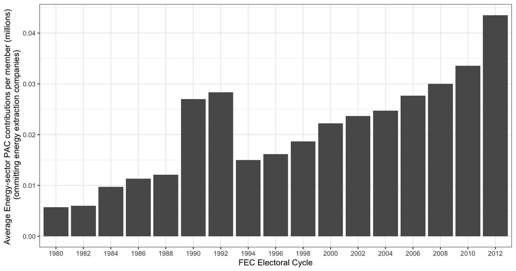

```r
# load DIME data
load(here("data/contrib_matrix.rds"))

contrib_matrix %<>%
  mutate(cycle = str_sub(ICPSR, -4)) %>%
  filter(cycle < 2014)

contrib_matrix %>%
  mutate(cycle = str_sub(ICPSR, -4)) %>%
  # FIXME
  filter(cycle <2014) %>%
  group_by(cycle, ICPSR) %>%
  summarise(total = sum(value, na.rm = TRUE)/1000000) %>%
  ungroup() %>%
  group_by(cycle) %>%
  summarise(mean = mean(total)) %>%
  ggplot() +
  aes(x = factor(cycle), y = mean) +
  geom_col() +
  labs(y = "Average Energy-sector PAC contributions per member (millions) \n (ommitting energy extraction companies)",
       x = "FEC Electoral Cycle")
```

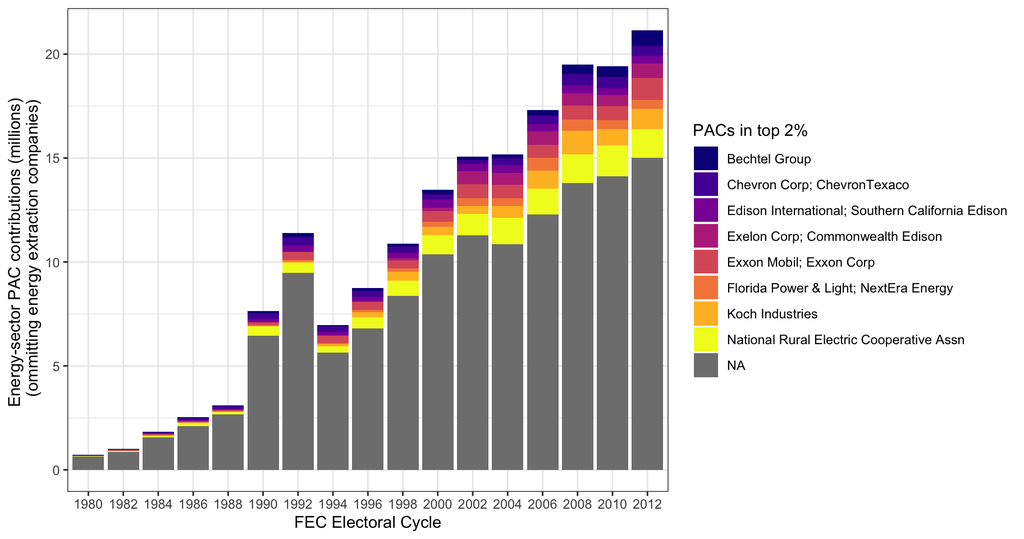

```r
contrib_matrix %>%
  mutate(cycle = str_sub(ICPSR, -4)) %>%
  # FIXME
  filter(cycle < 2014) %>%
  group_by(cycle, PACShort) %>%
  summarise(total = sum(value, na.rm = TRUE)/1000000) %>%  # millions
  ungroup() %>%
    group_by(PACShort) %>%
  mutate(PACtotal = sum(total, na.rm = TRUE)) %>%
  ungroup() %>%
  mutate(PAC = ifelse(PACtotal > quantile(PACtotal, .98), PACShort, NA)) %>%
  ggplot() +
  aes(x = factor(cycle), y = total, fill= PAC) +
  geom_col() +
  labs(y = "Energy-sector PAC contributions (millions) \n (ommitting energy extraction companies)",
       x = "FEC Electoral Cycle",
       fill = "PACs in top 2%") +
  scale_fill_viridis_d(option = "C", na.value = "grey50")
```

```r
contrib_matrix %>%
  mutate(cycle = str_sub(ICPSR, -4)) %>%
  # FIXME
  filter(cycle < 2014) %>%
  group_by(cycle, PACShort) %>%
  summarise(PACcycle = sum(value, na.rm = TRUE)) %>%
  ungroup() %>%
    group_by(PACShort) %>%
  mutate(PACtotal = sum(PACcycle, na.rm = TRUE)) %>%
  ungroup() %>%
  filter(PACtotal > quantile(PACtotal, .98)) %>%
  arrange(-as.numeric(cycle)) %>%
  kable()
```

| cycle | PACShort | PACcycle | PACtotal |
| --- | --- | --- | --- |
| 2012 | Bechtel Group | 749500 | 3314804 |
| 2012 | Chevron Corp; ChevronTexaco | 497000 | 4515758 |
| 2012 | Edison International; Southern California Edison | 357165 | 3875632 |
| 2012 | Exelon Corp; Commonwealth Edison | 704801 | 3997218 |
| 2012 | Exxon Mobil; Exxon Corp | 1034000 | 6661318 |
| 2012 | Florida Power & Light; NextEra Energy | 439500 | 3609045 |
| 2012 | Koch Industries | 979481 | 5924924 |
| 2012 | National Rural Electric Cooperative Assn | 1380100 | 11691384 |
| 2010 | Bechtel Group | 522500 | 3314804 |
| 2010 | Chevron Corp; ChevronTexaco | 531500 | 4515758 |
| 2010 | Edison International; Southern California Edison | 330020 | 3875632 |
| 2010 | Exelon Corp; Commonwealth Edison | 521899 | 3997218 |
| 2010 | Exxon Mobil; Exxon Corp | 687500 | 6661318 |
| 2010 | Florida Power & Light; NextEra Energy | 432750 | 3609045 |
| 2010 | Koch Industries | 776500 | 5924924 |
| 2010 | National Rural Electric Cooperative Assn | 1475000 | 11691384 |
| 2008 | Bechtel Group | 438000 | 3314804 |
| 2008 | Chevron Corp; ChevronTexaco | 543000 | 4515758 |
| 2008 | Edison International; Southern California Edison | 392200 | 3875632 |
| 2008 | Exelon Corp; Commonwealth Edison | 585399 | 3997218 |
| 2008 | Exxon Mobil; Exxon Corp | 668498 | 6661318 |
| 2008 | Florida Power & Light; NextEra Energy | 539000 | 3609045 |
| 2008 | Koch Industries | 1136000 | 5924924 |
| 2008 | National Rural Electric Cooperative Assn | 1388460 | 11691384 |
| 2006 | Bechtel Group | 269500 | 3314804 |
| 2006 | Chevron Corp; ChevronTexaco | 386350 | 4515758 |
| 2006 | Edison International; Southern California Edison | 367098 | 3875632 |
| 2006 | Exelon Corp; Commonwealth Edison | 633189 | 3997218 |
| 2006 | Exxon Mobil; Exxon Corp | 626950 | 6661318 |
| 2006 | Florida Power & Light; NextEra Energy | 632500 | 3609045 |

[output cut: 106 more lines]

```r
# mere with letters data, d
contrib_matrix %<>%
  dplyr::rename(icpsryear = ICPSR,
         PAC_contributions = value) %>%
  mutate(cycle = str_sub(icpsryear, -4),
         icpsr = as.numeric(str_remove(icpsryear, cycle)),
         cycle = as.numeric(cycle)) %>%
  filter(cycle > 1990)%>%
  left_join(d %>% select(icpsr, name_state, party) %>% distinct())
```

We identify 428 PACs in the energy sector (oil, gas, and electricity) and match their PAC contributions to each member of congress.

For example:

### The top PAC recipient in a single cycle

```r
letters_PACs <- d %>%
  #FIXME
  filter(cycle <2014) %>%
  filter(!is.na(ProBusiness)|!is.na(ProProject))%>%
  group_by(icpsryear, cycle, name_state, party) %>%
  summarise(ProBusiness_Letters = n()) %>%
  # join by ICPSR, adding a sum of sector PAC contributions per member
  left_join(contrib_matrix) %>%
  ungroup() %>%
  group_by(icpsr) %>%
  mutate(party = paste(unique(party), collapse = ";")) %>%
  mutate(party = str_remove(party, ";.*")) %>%
  ungroup()

letters_PACs_cycle <- letters_PACs %>%
  group_by(cycle, icpsr, name_state, party) %>%
  # delete PACs that did not give from list, but keep members that recieved no contributions
  mutate(PACShort = ifelse(PAC_contributions > 0, PACShort, NA)) %>%
  summarise(PAC_contributions = sum(PAC_contributions),
            PACs = paste(unique(PACShort), collapse = ";")) %>%
  ungroup() %>%
  arrange(-PAC_contributions)

letters_PACs_cycle %>% top_n(1, PAC_contributions) %>% knitr::kable()
```

| cycle | icpsr | name_state | party | PAC_contributions | PACs |
| --- | --- | --- | --- | --- | --- |
| 2010 | 15446 | UPTON, Frederick Stephen (R) - MI | (R) | 241200 | Valero Energy;FirstEnergy Corp; Ohio Edison;Exelon Corp; Commonwealth Edison;Koch Industries;National Rural Electric Cooperative Assn;EnviroCare of Utah;CMS Energy; Consumers Power Co;DTE Energy; Detr… |

### The top PAC recipient overall

```r
letters_PACs_total <- letters_PACs %>%
  ungroup() %>%
  group_by(icpsr, name_state) %>%
  summarise(PAC_contributions = sum(PAC_contributions),
            PACs = str_c(unique(PACShort), collapse = ";")) %>%
  filter(!is.na(name_state)) %>%
  ungroup()

letters_PACs_total %>% top_n(1, PAC_contributions) %>% knitr::kable()
```

[output not shown]

### Pro-business letters per cycle

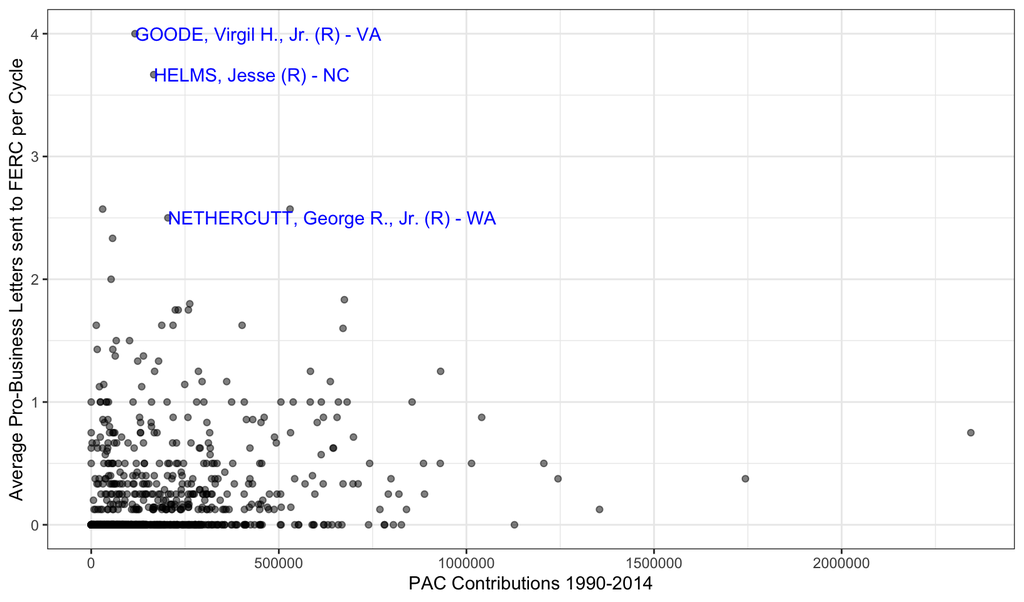

```r
top1 <- top_n(letters_money_total %>%
                filter(!is.na(name_state)), 5, PAC_contributions) %>%
  .$name_state

top2 <- top_n(letters_money_total, 5, ProBusiness_Letters_Per_Cycle) %>%
  .$name_state

letters_money_total %>%
  mutate(name_state = as.character(name_state)) %>%
  ggplot() +
  aes(x = PAC_contributions,
      y = ProBusiness_Letters_Per_Cycle) +
  geom_point(alpha = .5) +
  geom_text(aes(label = ifelse(name_state %in% top2,
                               name_state, NA)),
            check_overlap = TRUE,
            hjust = 0,
            color = "blue") +
  labs(x = "PAC Contributions 1990-2014",
       y = "Average Pro-Business Letters sent to FERC per Cycle")
```

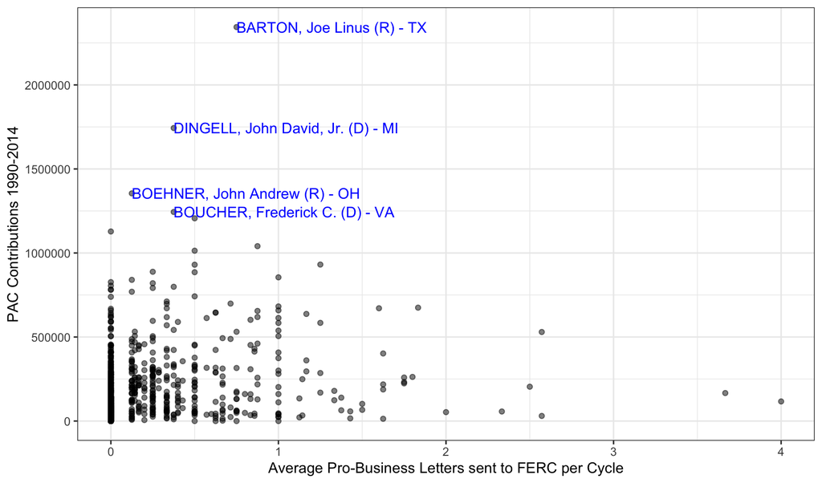

```r
letters_money_total %>%
  mutate(name_state = as.character(name_state)) %>%
  ggplot() +
  coord_flip() +
  aes(x = PAC_contributions,
      y = ProBusiness_Letters_Per_Cycle) +
  geom_point(alpha = .5) +
  geom_text(aes(label = ifelse(name_state %in% top1, name_state, NA)),
            check_overlap = TRUE,
            hjust = 0,
            color = "blue") +
  labs(x = "PAC Contributions 1990-2014",
       y = "Average Pro-Business Letters sent to FERC per Cycle")
```

```r
library(dplyr)

# MERGE IN LETTERS DATA TO PRO-BUSINESS LETTERS
# FIXME
# CALLE THIS Pro_letters and Antiletters Anti_letters
nrow(letters_money)
letters_money %<>% left_join(d %>%
dplyr::select(icpsryear, # nominate.dim1, #chair_since_2007,
              #oversight_committee,
              chamber) %>% distinct() #%>% dplyr::rename(chair_since_2000 = chair_since_2007)
) %>% distinct()
nrow(letters_money)

nrow(All_Letters_money)
All_Letters_money %<>% distinct() %>%
  left_join(d %>%
dplyr::select(icpsryear, #nominate.dim1, #chair_since_2007,
              #oversight_committee,
              chamber) %>% distinct() #%>% dplyr::rename(chair_since_2000 = chair_since_2007)
) %>% distinct()
nrow(All_Letters_money)

nrow(Antiletters_money)
Antiletters_money %<>% left_join(d %>%
dplyr::select(icpsryear, #nominate.dim1, chair_since_2007,
              #oversight_committee,
              chamber) %>% distinct() #%>% dplyr::rename(chair_since_2000 = chair_since_2007)
)%>% distinct()
nrow(Antiletters_money)

# MERGE IN LETTERS DATA TO NONCONSTITUENT LETTERS COUNTS
# TO DO
```

# Models

## Sector-level

### All Letters per cycle ~ Energy Sector PAC contributions per cycle 1998-2014

```r
mplot <- function(m){m %>%
  tidy(conf.int = TRUE) %>%
    filter(term!="(Intercept)") %>%
ggplot() +
  aes(x = term,
      y = estimate,
      ymin = conf.low,
      ymax = conf.high)+
    geom_hline(yintercept = 0, linetype =2) +
  geom_pointrange() + coord_flip() }

All_Letters_money %<>%
  mutate(Log_PAC_contributions = log(PAC_contributions+1))

mAll <- glm(All_Letters ~ PAC_contributions, data = All_Letters_money %>%
           mutate(PAC_contributions = PAC_contributions/1000000),
         family = poisson)
tidy(mAll)
```

```
## # A tibble: 2 x 5
##   term              estimate std.error statistic  p.value
##   <chr>                <dbl>     <dbl>     <dbl>    <dbl>
## 1 (Intercept)         -0.109    0.0176     -6.19 5.83e-10
## 2 PAC_contributions    2.42     0.294       8.24 1.79e-16
```

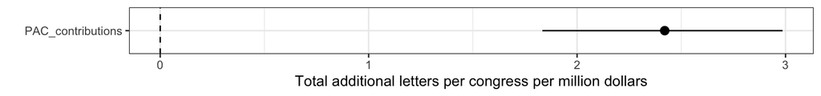

```r
mAll %>% mplot()+
  labs(x="", y="Total additional letters per congress per million dollars")
```

#### Pro-Business Letters per cycle ~ Energy Sector PAC contributions per cycle 1998-2014

```r
letters_money %<>%
  #drop_na(ProBusiness_Letters, PAC_contributions) %>%
  mutate(Log_PAC_contributions = log(PAC_contributions+1))

mPro <- glm(ProBusiness_Letters ~ PAC_contributions, data = letters_money %>% mutate(PAC_contributions = PAC_contributions/1000000), family = poisson)
tidy(mPro)
```

```
## # A tibble: 2 x 5
##   term              estimate std.error statistic  p.value
##   <chr>                <dbl>     <dbl>     <dbl>    <dbl>
## 1 (Intercept)          -1.47    0.0348    -42.3  0
## 2 PAC_contributions     2.27    0.591       3.83 0.000128
```

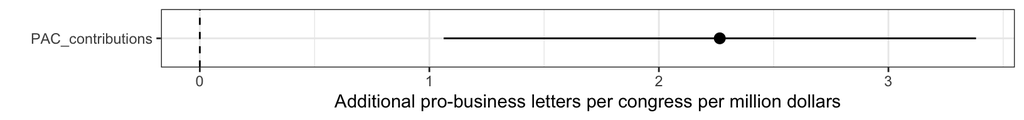

```r
mPro %>% mplot()+
  labs(x="", y="Additional pro-business letters per congress per million dollars")
```

```r
mProLog <- glm(ProBusiness_Letters ~ Log_PAC_contributions, data = letters_money, family = poisson  )
tidy(mProLog)
```

```
## # A tibble: 2 x 5
##   term                  estimate std.error statistic  p.value
##   <chr>                    <dbl>     <dbl>     <dbl>    <dbl>
## 1 (Intercept)            -1.74     0.0886     -19.6  2.33e-85
## 2 Log_PAC_contributions   0.0383   0.00947      4.04 5.36e- 5
```

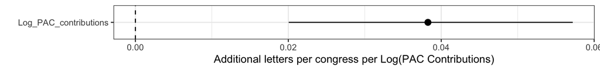

```r
mProLog %>% mplot()+
  labs(x="", y="Additional letters per congress per Log(PAC Contributions)")
```

```r
mNonConstituent <- glm(Non_Constituent_Letters ~ PAC_contributions, data = Non_Constituent_money, family = poisson  )
tidy(mNonConstituent)
```

```
## # A tibble: 2 x 5
##   term                 estimate   std.error statistic  p.value
##   <chr>                   <dbl>       <dbl>     <dbl>    <dbl>
## 1 (Intercept)       -0.109      0.0176          -6.19 5.83e-10
## 2 PAC_contributions  0.00000242 0.000000294      8.24 1.79e-16
```

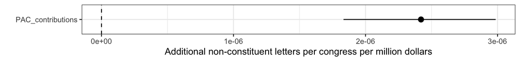

```r
mNonConstituent %>% mplot()+
  labs(x="", y="Additional non-constituent letters per congress per million dollars")
```

```r
mNonConstituentLog <- glm(Non_Constituent_Letters ~ Log_PAC_contributions, data = Non_Constituent_money %>% mutate(Log_PAC_contributions = log(PAC_contributions+1)), family = poisson  )
tidy(mNonConstituent)
```

```
## # A tibble: 2 x 5
##   term                 estimate   std.error statistic  p.value
##   <chr>                   <dbl>       <dbl>     <dbl>    <dbl>
## 1 (Intercept)       -0.109      0.0176          -6.19 5.83e-10
## 2 PAC_contributions  0.00000242 0.000000294      8.24 1.79e-16
```

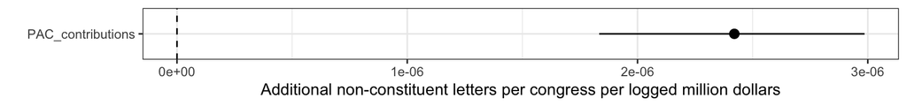

```r
mNonConstituent %>% mplot()+
  labs(x="", y="Additional non-constituent letters per congress per logged million dollars")
```

#### By party

```r
mProParty <- glm(ProBusiness_Letters ~ party, data = letters_money %>% filter(!party %in% c("NA","(I)", "Independent")), family = "poisson" )

tidy(mProParty)
```

```
## # A tibble: 2 x 5
##   term        estimate std.error statistic   p.value
##   <chr>          <dbl>     <dbl>     <dbl>     <dbl>
## 1 (Intercept)   -1.14     0.0410    -27.7  1.39e-168
## 2 party(R)       0.133    0.0566      2.35 1.88e-  2
```

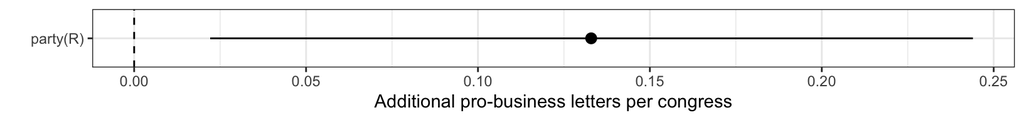

```r
mplot(mProParty) +
  labs(x="", y="Additional pro-business letters per congress")
```

```r
# PAC + party:
mPro_pac_party<- glm(ProBusiness_Letters ~ PAC_contributions + party,
                     data = letters_money %>%
                       filter(!party %in% c("NA","(I)", "Independent"))%>%
                       mutate(PAC_contributions = PAC_contributions/1000000), family = "poisson" )

tidy(mPro_pac_party)
```

```
## # A tibble: 3 x 5
##   term              estimate std.error statistic   p.value
##   <chr>                <dbl>     <dbl>     <dbl>     <dbl>
## 1 (Intercept)        -1.17      0.0439    -26.7  8.29e-157
## 2 PAC_contributions   0.694     0.638       1.09 2.77e-  1
## 3 party(R)            0.0618    0.0598      1.03 3.01e-  1
```

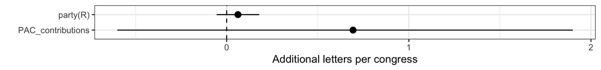

```r
mplot(mPro_pac_party)+
  labs(x="", y="Additional letters per congress")
```

```r
# PAC*party interaction:
mPro_pacXparty<-glm(ProBusiness_Letters ~ PAC_contributions * party,
                    data = letters_money %>%
                      filter(!party %in% c("NA","(I)", "Independent"))%>%
                      mutate(PAC_contributions = PAC_contributions/1000000), family = "poisson" )

tidy(mPro_pacXparty)
```

```
## # A tibble: 4 x 5
##   term                       estimate std.error statistic   p.value
##   <chr>                         <dbl>     <dbl>     <dbl>     <dbl>
## 1 (Intercept)                 -1.16      0.0493  -23.5    7.68e-122
## 2 PAC_contributions            0.0357    1.25      0.0286 9.77e-  1
## 3 party(R)                     0.0372    0.0714    0.520  6.03e-  1
## 4 PAC_contributions:party(R)   0.904     1.45      0.624  5.33e-  1
```

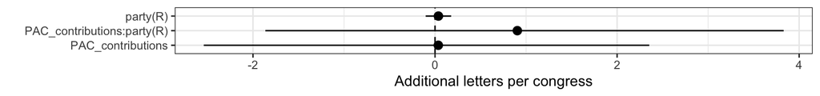

```r
mplot(mPro_pacXparty)+
  labs(x="", y="Additional letters per congress")
```

```r
# DW NOMINATE
#mPro_nominate <-glm(ProBusiness_Letters ~  nominate.dim1, data = letters_money %>% filter(!party %in% c("NA","(I)", "Independent"))%>% mutate(PAC_contributions = PAC_contributions/1000000), family = "poisson" )
#tidy(mPro_nominate)
#mplot(mPro_nominate)+labs(x="", y="Additional letters per congress")

# PAC + ideology:
# mPro_pac_nominate <-glm(ProBusiness_Letters ~ PAC_contributions * nominate.dim1, data = letters_money %>% filter(!party %in% c("NA","(I)", "Independent"))%>% mutate(PAC_contributions = PAC_contributions/1000000), family = "poisson" )

# tidy(mPro_pac_nominate)

# mplot(mPro_pac_nominate)+ labs(x="", y="Additional letters per congress")
```

#### Full (multivariate) models

```r
# Full model, all letters
mAll_Full <- glm(All_Letters ~ PAC_contributions + party, data = All_Letters_money %>%
                   filter(!party %in% c("NA","(I)", "Independent"))%>% mutate(PAC_contributions = PAC_contributions/1000000), family = "poisson" )

tidy(mAll_Full)
```

```
## # A tibble: 3 x 5
##   term              estimate std.error statistic  p.value
##   <chr>                <dbl>     <dbl>     <dbl>    <dbl>
## 1 (Intercept)          0.293    0.0211     13.9  6.90e-44
## 2 PAC_contributions    1.43     0.310       4.61 4.00e- 6
## 3 party(R)            -0.189    0.0303     -6.23 4.55e-10
```

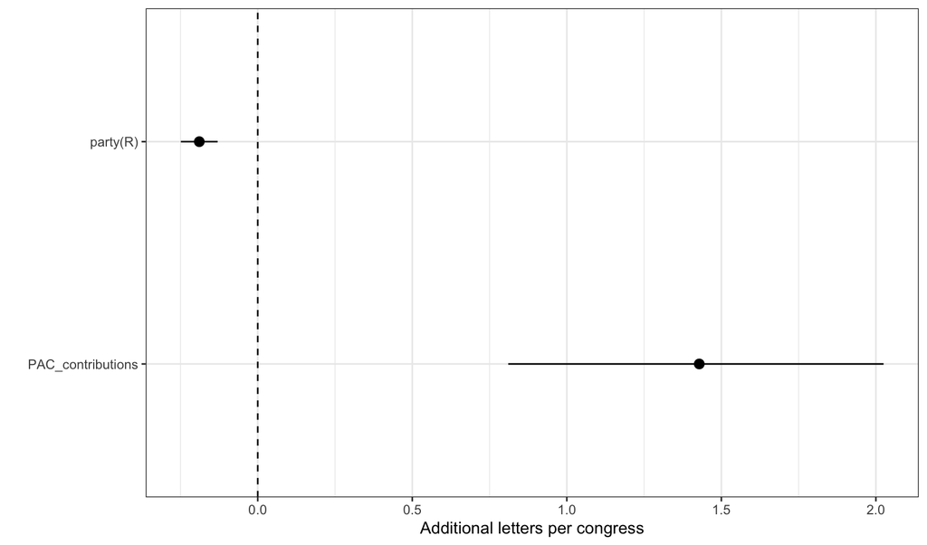

```r
mplot(mAll_Full)+
  labs(x="", y="Additional letters per congress")
```

```r
# Full model with interaction:
mAll_Fullx <- glm(All_Letters ~ PAC_contributions*party, data = All_Letters_money %>% filter(!party %in% c("NA","(I)", "Independent"))%>% mutate(PAC_contributions = PAC_contributions/1000000), family = "poisson" )

tidy(mAll_Fullx)
```

```
## # A tibble: 4 x 5
##   term                       estimate std.error statistic  p.value
##   <chr>                         <dbl>     <dbl>     <dbl>    <dbl>
## 1 (Intercept)                   0.306    0.0234     13.0  7.79e-39
## 2 PAC_contributions             0.863    0.563       1.53 1.25e- 1
## 3 party(R)                     -0.213    0.0362     -5.90 3.67e- 9
## 4 PAC_contributions:party(R)    0.824    0.673       1.23 2.21e- 1
```

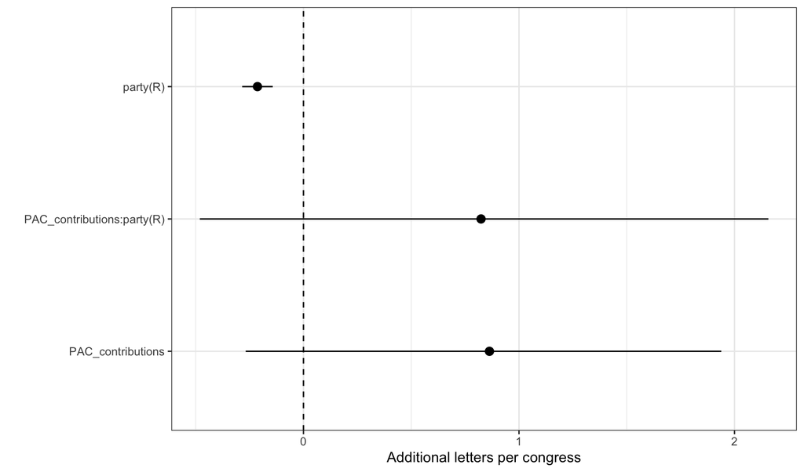

```r
mplot(mAll_Fullx)+
  labs(x="", y="Additional letters per congress")
```

```r
# Full model, pro business letters
mPro_Full <- glm(ProBusiness_Letters ~ PAC_contributions + party, data = letters_money %>% filter(!party %in% c("NA","(I)", "Independent"))%>% mutate(PAC_contributions = PAC_contributions/1000000), family = "poisson" )

tidy(mPro_Full)
```

```
## # A tibble: 3 x 5
##   term              estimate std.error statistic   p.value
##   <chr>                <dbl>     <dbl>     <dbl>     <dbl>
## 1 (Intercept)        -1.17      0.0439    -26.7  8.29e-157
## 2 PAC_contributions   0.694     0.638       1.09 2.77e-  1
## 3 party(R)            0.0618    0.0598      1.03 3.01e-  1
```

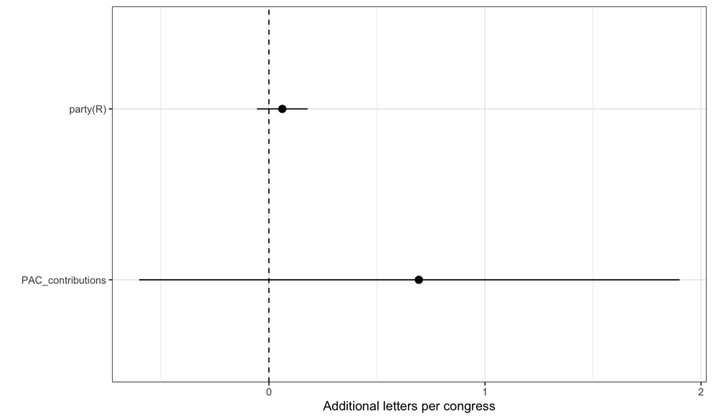

```r
mplot(mPro_Full)+
  labs(x="", y="Additional letters per congress")
```